# Interpopulation differences in developmental plasticity of carnivores determine the emergence of a trophic interaction

Supplementary material

Keisuke Atsumi, Samuel R.P-J. Ross and Osamu Kishida

21/02/23 19:39

This supplementary material includes all analytic code, data descriptions and appendices.

# Setup

### Load packages

```r
rm(list=ls())  # reset workspace

pacman::p_load(
 openxlsx    # open excel file
 , lubridate # dates
 , RcppRoll  # window functions
 , tidyverse
 , magrittr  # Extend pipe
 , knitr     # rmarkdown
 , kableExtra # nice tables
 , pander     # nice tables
 , agricolae  # Tukey
 , patchwork
)
opts_chunk$set(
  prompt=TRUE, message=FALSE, comment="", warning = FALSE
  )
options(
  knitr.kable.NA = '',
  scipen=100           # do not show numbers using exponential
  )
```

### Load original functions

`SRH_fun`: Return results of Scheirer–Ray–Hare (SRH) test

`tukey.stats` : Return results of Tukey HSD post-hoc comparison

`ANOVA_stats` : Return results of ANOVA

```r
> #' Title: SRH_fun
> #' Show main results of SRH test in table
> #' @param model: $coefficients of glm summary
> SRH_fun <- function(x, mod = " ") {
+
+   # calculate mean sq for total as sum(sum sq)/sum(Df)
+   ms_total <- sum(summary(x)[[1]][,2])/sum(summary(x)[[1]][,1])
+
+   # create dataframe for Scheirer-Ray-Hare output
+   SRH.out <- as.data.frame(matrix(rownames(summary(x)[[1]])[c(1:nrow(summary(x)[[1]])-1)])) %>%
+     rename("Factor" = "V1") %>%
+     mutate(Df = summary(x)[[1]][c(1:nrow(summary(x)[[1]])-1),1])
+
+   for (h in 1:nrow(SRH.out)) {
+     # get S-R-H test statistic
+     SRH.out$SRH[h]<-(summary(x)[[1]][h,2])/ms_total
+   }
+
+   # add asterisk for significance
+   SRH.out.table <- SRH.out %>%
+     mutate(
+       # calculate P-value using test statistic and degrees of freedom
+       P = 1 - pchisq(SRH, Df),
+       Significance = ifelse(P < 0.05, "*", "")
+       )
+
+   return(list(
+     SRH.out.table = SRH.out.table, SRH.out = SRH.out)
+     )
+
+ }
>
> #' Title: tukey.stats
> #' Show main results of Tukey in table
> #' @param model: tukey result from function HSD.test
> tukey.stats <- function(tukey, mod = " ") {
+   left_join(
+     tukey$means %>%
+       mutate(Treat = rownames(.)) %>%
+       mutate_if(is.numeric, round, 2) %>%
+       mutate(
+         meanSE = str_c(.[, 1], std, sep = "±")
+         ) %>%
+       # arrange(desc(.[,1])) %>%
+       dplyr::select(Treat, meanSE),
+     tukey$groups %>% dplyr::select(groups) %>%
+       mutate(Treat = rownames(.))
+     )
+ }
>
>
> # Plot settings
> mytheme <- theme(
+     axis.text.x = element_text(size=12, angle = -40, hjust = 0),
+     axis.text.y = element_text(size=12),
+     axis.title.x = element_text(size=13),
+     axis.title.y = element_text(size=13),
+     legend.text = element_text(size=12),
+     legend.title = element_text(size=12),
+     panel.background=element_rect(fill='white', colour='black', size=0.3),
+     panel.grid=element_blank()
+     )
> cbPalette.full <-
+   c("#999999", "#E69F00", "#56B4E9", "#009E73", "#0072B2", "#D55E00", "#CC79A7")
>
>
> #' Title: ANOVA_stats
> #' Show main results of ANOVA in table
> #' @param model: $coefficients of glm summary
> ANOVA_stats <- function(model, mod = " ") {
+   model %>%
+     as.data.frame() %>%
+     rownames_to_column("Factors") %>%
+     rename("Pval" = "Pr(>F)", "F" = "F value", "d.f." = "Df", "SS" = "Sum Sq")  %>%
+     mutate_at("Pval", round, 3) %>%
+     mutate(P = ifelse(Pval == 0, "<0.001", Pval)) %>%
+     dplyr::select("Factors", "SS", "d.f.", "F", "P") %>%
+     mutate(significance = ifelse(P < 0.05, "+", ""))
+ }
```

```r
> # Caption
> cap <- data.frame(
+   desc = c(
+     "Salamander mortality
+     (count) by day 18",
+     "Tadpole mortality
+     (count) by day 32"
+     )
+   ) %>%
+   mutate_all(as.character)
> row.names(cap) <- c("sal", "tad")
>
> # Export experimental settings of each tank
> IDs <- read.xlsx('./Data.xlsx', sheet = "Count") %>%
+   dplyr::select(ID:HatchTiming) %>%
+   mutate_all(as.factor) %>%
+   mutate(
+     # Combination of genetic strains of salamander & tadpole
+     SalxTad = str_c(.$Sal, .$Tad, sep = " "),
+     SizexSal = str_c(.$Size, .$Sal, sep = " "),
+     # Full treatment conditions = "Treat"
+     Treat = str_c(.$Size, .$Sal, .$Tad, sep = " "),
+     SalxTadxHatchtiming = str_c(Sal, Tad, HatchTiming, sep = " ")
+     )  %>%
+   mutate_all(as.factor)
```

# Interaction strength

### Original data description

**ID** : Tank ID

**Size** : Initial salamander size distribution.

- *Homo*, homogenous - suppressing salamander cannibalism
- *Hetero*, heterogenous - facilitating salamander cannibalism

**Sal** : Salamander geographic population identity

**Tad** : Tadpole geographic population identity

**Hatchtiming** : Salamander hatch timing conditions.

- *mix*, initial size heterogenous treatment
- *early*, early hatch timing sub-treatment of initial size homogenous treatment
- *late*, late hatch timing sub-treatment of initial size homogenous treatment

**N.[sal OR tad]..[date]** : Counts of survived salamanders or tadpoles at the date

**Meta.[sal OR tad]..[date]** : Counts of metamorphosized salamanders or tadpoles every week (by the date)

**Mort.[sal OR tad]..[date]** : Counts of dead salamanders or tadpoles every week (calculated using weekly reduction of surviving individuals and metamorphosis counts)

```r
> raw.dat  <- read.xlsx('./Data.xlsx', sheet = "Count") %>%
+   mutate_at(vars(ID:Tad), funs(as.factor(.))) %>%
+   # treat mortality and metamorphism data as numeric
+   mutate_at(vars(contains("Meta")), funs(as.numeric(.))) %>%
+   mutate_at(vars(contains("Mort")), funs(as.numeric(.)))
>
> raw.dat %>%
+   kable("html") %>% kable_styling("striped", position = "left") %>%
+   scroll_box(width = "100%", height = "300px")
```

| ID | Size | Sal | Tad | HatchTiming | N.tad..06.18 | N.sal..06.18 | Meta.tad..06.18 | Meta.sal..06.18 | Mort.tad..06.18 | Mort.sal..06.18 | N.tad..06.11 | N.sal..06.11 | Meta.tad..06.11 | Meta.sal..06.11 | Mort.tad..06.11 | Mort.sal..06.11 | N.tad..06.04 | N.sal..06.04 | Meta.tad..06.04 | Meta.sal..06.04 | Mort.tad..06.04 | Mort.sal..06.04 | N.tad..05.28 | N.sal..05.28 | Meta.tad..05.28 | Meta.sal..05.28 | Mort.tad..05.28 | Mort.sal..05.28 | N.tad..05.25 | … |
| --- | --- | --- | --- | --- | --- | --- | --- | --- | --- | --- | --- | --- | --- | --- | --- | --- | --- | --- | --- | --- | --- | --- | --- | --- | --- | --- | --- | --- | --- | --- |
| 1 | Hetero | Erimo | Erimo | Mix | 23 | 3 | 0 | 0 | 3 | 0 | 26 | 3 | 0 | 0 | 4 | 3 | 30 | 6 | 0 | 0 | 0 | 6 | 30 | 12 | 0 | 0 | 0 | 3 | 30 | … |
| 2 | Hetero | Erimo | Erimo | Mix | 27 | 3 | 0 | 0 | 1 | 0 | 28 | 3 | 0 | 0 | 2 | 2 | 30 | 5 | 0 | 0 | 0 | 4 | 30 | 9 | 0 | 0 | 0 | 4 | 30 | … |
| 3 | Hetero | Erimo | Erimo | Mix | 25 | 5 | 0 | 0 | 1 | 4 | 26 | 9 | 0 | 0 | 4 | 1 | 30 | 10 | 0 | 0 | 0 | 2 | 30 | 12 | 0 | 0 | 0 | 3 | 30 | … |
| 4 | Hetero | Erimo | Erimo | Mix | 29 | 5 | 0 | 0 | 0 | 0 | 29 | 5 | 0 | 0 | 1 | 0 | 30 | 5 | 0 | 0 | 0 | 5 | 30 | 10 | 0 | 0 | 0 | 5 | 30 | … |
| 5 | Hetero | Erimo | Erimo | Mix | 27 | 7 | 0 | 0 | 2 | 2 | 29 | 9 | 0 | 0 | 0 | 3 | 29 | 12 | 0 | 0 | 0 | 1 | 29 | 13 | 0 | 0 | 0 | 2 | 29 | … |
| 6 | Hetero | Erimo | Erimo | Mix | 29 | 5 | 0 | 0 | 0 | 0 | 29 | 5 | 0 | 0 | 1 | 1 | 30 | 6 | 0 | 0 | 0 | 4 | 30 | 10 | 0 | 0 | 0 | 5 | 30 | … |
| 7 | Hetero | Erimo | Erimo | Mix | 26 | 4 | 0 | 0 | 2 | 0 | 28 | 4 | 0 | 0 | 1 | 0 | 29 | 4 | 0 | 0 | 1 | 7 | 30 | 11 | 0 | 0 | 0 | 4 | 30 | … |
| 8 | Hetero | Erimo | Erimo | Mix | 29 | 5 | 0 | 0 | 0 | 0 | 29 | 5 | 0 | 0 | 0 | 0 | 29 | 5 | 0 | 0 | 1 | 6 | 30 | 11 | 0 | 0 | 0 | 4 | 30 | … |
| 9 | Hetero | Erimo | Erimo | Mix | 28 | 4 | 0 | 0 | 1 | 1 | 29 | 5 | 0 | 0 | 1 | 0 | 30 | 5 | 0 | 0 | 0 | 6 | 30 | 11 | 0 | 0 | 0 | 4 | 30 | … |
| 10 | Hetero | Erimo | Erimo | Mix | 26 | 4 | 0 | 0 | 4 | 0 | 30 | 4 | 0 | 0 | 0 | 7 | 30 | 11 | 0 | 0 | 0 | 0 | 30 | 11 | 0 | 0 | 0 | 4 | 30 | … |
| 11 | Hetero | Chitose | Erimo | Mix | 30 | 2 | 0 | 0 | 0 | 1 | 30 | 3 | 0 | 0 | 0 | 5 | 30 | 8 | 0 | 0 | 0 | 5 | 30 | 13 | 0 | 0 | 0 | 2 | 30 | … |
| 12 | Hetero | Chitose | Erimo | Mix | 30 | 2 | 0 | 0 | 0 | 4 | 30 | 6 | 0 | 0 | 0 | 4 | 30 | 10 | 0 | 0 | 0 | 4 | 30 | 14 | 0 | 0 | 0 | 1 | 30 | … |
| 13 | Hetero | Chitose | Erimo | Mix | 30 | 10 | 0 | 0 | 0 | 3 | 30 | 13 | 0 | 0 | 0 | 0 | 30 | 13 | 0 | 0 | 0 | 0 | 30 | 13 | 0 | 0 | 0 | 2 | 30 | … |
| 14 | Hetero | Chitose | Erimo | Mix | 30 | 7 | 0 | 0 | 0 | 1 | 30 | 8 | 0 | 0 | 0 | 2 | 30 | 10 | 0 | 0 | 0 | 4 | 30 | 14 | 0 | 0 | 0 | 1 | 30 | … |
| 15 | Hetero | Chitose | Erimo | Mix | 29 | 3 | 0 | 0 | 0 | 2 | 29 | 5 | 0 | 0 | 1 | 4 | 30 | 9 | 0 | 0 | 0 | 3 | 30 | 12 | 0 | 0 | 0 | 3 | 30 | … |
| 16 | Hetero | Chitose | Erimo | Mix | 30 | 7 | 0 | 0 | 0 | 4 | 30 | 11 | 0 | 0 | 0 | 4 | 30 | 15 | 0 | 0 | 0 | 0 | 30 | 15 | 0 | 0 | 0 | 0 | 30 | … |
| 17 | Hetero | Chitose | Erimo | Mix | 30 | 10 | 0 | 0 | 0 | 1 | 30 | 11 | 0 | 0 | 0 | 2 | 30 | 13 | 0 | 0 | 0 | 1 | 30 | 14 | 0 | 0 | 0 | 1 | 30 | … |
| 18 | Hetero | Chitose | Erimo | Mix | 30 | 15 | 0 | 0 | 0 | 0 | 30 | 15 | 0 | 0 | 0 | 0 | 30 | 15 | 0 | 0 | 0 | 0 | 30 | 15 | 0 | 0 | 0 | 0 | 30 | … |
| 19 | Hetero | Chitose | Erimo | Mix | 30 | 14 | 0 | 0 | 0 | 0 | 30 | 14 | 0 | 0 | 0 | 0 | 30 | 14 | 0 | 0 | 0 | 0 | 30 | 14 | 0 | 0 | 0 | 1 | 30 | … |
| 20 | Hetero | Chitose | Erimo | Mix | 29 | 14 | 0 | 0 | 0 | 0 | 29 | 14 | 0 | 0 | 0 | 1 | 29 | 15 | 0 | 0 | 0 | 0 | 29 | 15 | 0 | 0 | 0 | 0 | 29 | … |
| 21 | Hetero | Erimo | Chitose | Mix | 28 | 10 | 0 | 0 | 2 | 0 | 30 | 10 | 0 | 0 | 0 | 3 | 30 | 13 | 0 | 0 | 0 | 1 | 30 | 14 | 0 | 0 | 0 | 1 | 30 | … |
| 22 | Hetero | Erimo | Chitose | Mix | 26 | 10 | 0 | 0 | 1 | 2 | 27 | 12 | 0 | 0 | 3 | 1 | 30 | 13 | 0 | 0 | 0 | 1 | 30 | 14 | 0 | 0 | 0 | 1 | 30 | … |
| 23 | Hetero | Erimo | Chitose | Mix | 25 | 5 | 0 | 0 | 2 | 0 | 27 | 5 | 0 | 0 | 3 | 2 | 30 | 7 | 0 | 0 | 0 | 4 | 30 | 11 | 0 | 0 | 0 | 4 | 30 | … |
| 24 | Hetero | Erimo | Chitose | Mix | 25 | 4 | 0 | 0 | 2 | 1 | 27 | 5 | 0 | 0 | 3 | 2 | 30 | 7 | 0 | 0 | 0 | 6 | 30 | 13 | 0 | 0 | 0 | 2 | 30 | … |
| 25 | Hetero | Erimo | Chitose | Mix | 19 | 4 | 0 | 0 | 6 | 0 | 25 | 4 | 0 | 0 | 5 | 1 | 30 | 5 | 0 | 0 | 0 | 3 | 30 | 8 | 0 | 0 | 0 | 7 | 30 | … |
| 26 | Hetero | Erimo | Chitose | Mix | 26 | 4 | 0 | 0 | 2 | 1 | 28 | 5 | 0 | 0 | 1 | 1 | 29 | 6 | 0 | 0 | 1 | 4 | 30 | 10 | 0 | 0 | 0 | 5 | 30 | … |
| 27 | Hetero | Erimo | Chitose | Mix | 30 | 5 | 0 | 0 | 0 | 0 | 30 | 5 | 0 | 0 | 0 | 0 | 30 | 5 | 0 | 0 | 0 | 3 | 30 | 8 | 0 | 0 | 0 | 7 | 30 | … |
| 28 | Hetero | Erimo | Chitose | Mix | 24 | 5 | 0 | 0 | 4 | 1 | 28 | 6 | 0 | 0 | 2 | 3 | 30 | 9 | 0 | 0 | 0 | 3 | 30 | 13 | 0 | 0 | 0 | 2 | 30 | … |
| 30 | Hetero | Erimo | Chitose | Mix | 21 | 5 | 0 | 0 | 5 | 0 | 26 | 5 | 0 | 0 | 3 | 1 | 29 | 6 | 0 | 0 | 1 | 8 | 30 | 14 | 0 | 0 | 0 | 1 | 30 | … |
| 31 | Hetero | Chitose | Chitose | Mix | 29 | 7 | 0 | 0 | 1 | 2 | 30 | 9 | 0 | 0 | 0 | 3 | 30 | 12 | 0 | 0 | 0 | 1 | 30 | 13 | 0 | 0 | 0 | 2 | 30 | … |
| 32 | Hetero | Chitose | Chitose | Mix | 30 | 13 | 0 | 0 | 0 | 0 | 30 | 13 | 0 | 0 | 0 | 0 | 30 | 13 | 0 | 0 | 0 | 0 | 30 | 13 | 0 | 0 | 0 | 0 | 30 | … |
| 33 | Hetero | Chitose | Chitose | Mix | 28 | 5 | 0 | 0 | 1 | 1 | 29 | 6 | 0 | 0 | 0 | 4 | 29 | 10 | 0 | 0 | 0 | 2 | 29 | 12 | 0 | 0 | 0 | 3 | 29 | … |
| 34 | Hetero | Chitose | Chitose | Mix | 30 | 8 | 0 | 0 | 0 | 3 | 30 | 11 | 0 | 0 | 0 | 2 | 30 | 13 | 0 | 0 | 0 | 0 | 30 | 13 | 0 | 0 | 0 | 2 | 30 | … |
| 35 | Hetero | Chitose | Chitose | Mix | 30 | 3 | 0 | 0 | 0 | 2 | 30 | 5 | 0 | 0 | 0 | 5 | 30 | 10 | 0 | 0 | 0 | 5 | 30 | 15 | 0 | 0 | 0 | 0 | 30 | … |
| 36 | Hetero | Chitose | Chitose | Mix | 30 | 15 | 0 | 0 | 0 | 0 | 30 | 15 | 0 | 0 | 0 | 0 | 30 | 15 | 0 | 0 | 0 | 0 | 30 | 15 | 0 | 0 | 0 | 0 | 30 | … |
| 37 | Hetero | Chitose | Chitose | Mix | 30 | 6 | 0 | 0 | 0 | 5 | 30 | 11 | 0 | 0 | 0 | 1 | 30 | 12 | 0 | 0 | 0 | 2 | 30 | 14 | 0 | 0 | 0 | 1 | 30 | … |
| 38 | Hetero | Chitose | Chitose | Mix | 30 | 12 | 0 | 0 | 0 | 0 | 30 | 12 | 0 | 0 | 0 | 0 | 30 | 12 | 0 | 0 | 0 | 0 | 30 | 12 | 0 | 0 | 0 | 3 | 30 | … |
| 39 | Hetero | Chitose | Chitose | Mix | 29 | 3 | 0 | 0 | 1 | 4 | 30 | 7 | 0 | 0 | 0 | 4 | 30 | 11 | 0 | 0 | 0 | 1 | 30 | 12 | 0 | 0 | 0 | 3 | 30 | … |
| 40 | Hetero | Chitose | Chitose | Mix | 30 | 15 | 0 | 0 | 0 | 0 | 30 | 15 | 0 | 0 | 0 | 0 | 30 | 15 | 0 | 0 | 0 | 0 | 30 | 15 | 0 | 0 | 0 | 0 | 30 | … |
| 41 | Homo | Erimo | Erimo | Early | 30 | 15 | 0 | 0 | 0 | 0 | 30 | 15 | 0 | 0 | 0 | 0 | 30 | 15 | 0 | 0 | 0 | 0 | 30 | 15 | 0 | 0 | 0 | 0 | 30 | … |
| 42 | Homo | Erimo | Erimo | Early | 30 | 15 | 0 | 0 | 0 | 0 | 30 | 15 | 0 | 0 | 0 | 0 | 30 | 15 | 0 | 0 | 0 | 0 | 30 | 15 | 0 | 0 | 0 | 0 | 30 | … |
| 43 | Homo | Erimo | Erimo | Early | 29 | 13 | 0 | 0 | 0 | 0 | 29 | 13 | 0 | 0 | 1 | 0 | 30 | 13 | 0 | 0 | 0 | 0 | 30 | 13 | 0 | 0 | 0 | 1 | 30 | … |
| 44 | Homo | Erimo | Erimo | Early | 30 | 15 | 0 | 0 | 0 | 0 | 30 | 15 | 0 | 0 | 0 | 0 | 30 | 15 | 0 | 0 | 0 | 0 | 30 | 15 | 0 | 0 | 0 | 0 | 30 | … |
| 45 | Homo | Erimo | Erimo | Early | 30 | 11 | 0 | 0 | 0 | 4 | 30 | 15 | 0 | 0 | 0 | 0 | 30 | 15 | 0 | 0 | 0 | 0 | 30 | 15 | 0 | 0 | 0 | 0 | 30 | … |
| 46 | Homo | Erimo | Erimo | Late | 29 | 15 | 0 | 0 | 0 | 0 | 29 | 15 | 0 | 0 | 0 | 0 | 29 | 15 | 0 | 0 | 1 | 0 | 30 | 15 | 0 | 0 | 0 | 0 | 30 | … |
| 47 | Homo | Erimo | Erimo | Late | 29 | 14 | 0 | 0 | 0 | 0 | 29 | 14 | 0 | 0 | 0 | 0 | 29 | 14 | 0 | 0 | 1 | 0 | 30 | 14 | 0 | 0 | 0 | 1 | 30 | … |
| 48 | Homo | Erimo | Erimo | Late | 30 | 14 | 0 | 0 | 0 | 0 | 30 | 14 | 0 | 0 | 0 | 0 | 30 | 14 | 0 | 0 | 0 | 0 | 28 | 14 | 0 | 0 | 0 | 1 | 30 | … |
| 49 | Homo | Erimo | Erimo | Late | 29 | 15 | 0 | 0 | 1 | 0 | 30 | 15 | 0 | 0 | 0 | 0 | 30 | 15 | 0 | 0 | 0 | 0 | 30 | 15 | 0 | 0 | 0 | 0 | 30 | … |
| 50 | Homo | Erimo | Erimo | Late | 30 | 14 | 0 | 0 | 0 | 0 | 30 | 14 | 0 | 0 | 0 | 0 | 30 | 14 | 0 | 0 | 0 | 0 | 30 | 14 | 0 | 0 | 0 | 1 | 30 | … |
| 51 | Homo | Chitose | Erimo | Early | 30 | 13 | 0 | 0 | 0 | 0 | 30 | 13 | 0 | 0 | 0 | 1 | 30 | 14 | 0 | 0 | 0 | 0 | 30 | 14 | 0 | 0 | 0 | 1 | 30 | … |
| 52 | Homo | Chitose | Erimo | Early | 30 | 14 | 0 | 0 | 0 | 0 | 30 | 14 | 0 | 0 | 0 | 0 | 30 | 14 | 0 | 0 | 0 | 0 | 30 | 14 | 0 | 0 | 0 | 0 | 30 | … |
| 53 | Homo | Chitose | Erimo | Early | 30 | 11 | 0 | 0 | 0 | 0 | 30 | 11 | 0 | 0 | 0 | 0 | 30 | 13 | 0 | 0 | 0 | 1 | 30 | 14 | 0 | 0 | 0 | 1 | 30 | … |
| 54 | Homo | Chitose | Erimo | Early | 30 | 12 | 0 | 0 | 0 | 1 | 30 | 13 | 0 | 0 | 0 | 0 | 30 | 13 | 0 | 0 | 0 | 0 | 30 | 13 | 0 | 0 | 0 | 0 | 30 | … |
| 55 | Homo | Chitose | Erimo | Early | 29 | 14 | 0 | 0 | 0 | 0 | 29 | 14 | 0 | 0 | 1 | 0 | 30 | 14 | 0 | 0 | 0 | 0 | 30 | 14 | 0 | 0 | 0 | 1 | 30 | … |
| 56 | Homo | Chitose | Erimo | Late | 30 | 15 | 0 | 0 | 0 | 0 | 30 | 15 | 0 | 0 | 0 | 0 | 30 | 15 | 0 | 0 | 0 | 0 | 30 | 15 | 0 | 0 | 0 | 0 | 30 | … |
| 57 | Homo | Chitose | Erimo | Late | 30 | 12 | 0 | 0 | 0 | 0 | 30 | 12 | 0 | 0 | 0 | 0 | 30 | 12 | 0 | 0 | 0 | 2 | 30 | 14 | 0 | 0 | 0 | 1 | 30 | … |
| 58 | Homo | Chitose | Erimo | Late | 30 | 15 | 0 | 0 | 0 | 0 | 30 | 15 | 0 | 0 | 0 | 0 | 30 | 15 | 0 | 0 | 0 | 0 | 30 | 15 | 0 | 0 | 0 | 0 | 30 | … |
| 59 | Homo | Chitose | Erimo | Late | 30 | 15 | 0 | 0 | 0 | 0 | 30 | 15 | 0 | 0 | 0 | 0 | 30 | 15 | 0 | 0 | 0 | 0 | 30 | 15 | 0 | 0 | 0 | 0 | 30 | … |
| 60 | Homo | Chitose | Erimo | Late | 30 | 14 | 0 | 0 | 0 | 0 | 30 | 14 | 0 | 0 | 0 | 0 | 30 | 14 | 0 | 0 | 0 | 1 | 30 | 15 | 0 | 0 | 0 | 0 | 30 | … |
| 61 | Homo | Erimo | Chitose | Early | 29 | 14 | 0 | 0 | 0 | 0 | 29 | 14 | 0 | 0 | 1 | 1 | 30 | 15 | 0 | 0 | 0 | 0 | 30 | 15 | 0 | 0 | 0 | 0 | 30 | … |
| 62 | Homo | Erimo | Chitose | Early | 30 | 15 | 0 | 0 | 0 | 0 | 30 | 15 | 0 | 0 | 0 | 0 | 30 | 15 | 0 | 0 | 0 | 0 | 30 | 15 | 0 | 0 | 0 | 0 | 30 | … |
| 63 | Homo | Erimo | Chitose | Early | 29 | 12 | 0 | 0 | 1 | 0 | 30 | 12 | 0 | 0 | 0 | 2 | 30 | 14 | 0 | 0 | 0 | 1 | 30 | 15 | 0 | 0 | 0 | 0 | 30 | … |
| 64 | Homo | Erimo | Chitose | Early | 30 | 14 | 0 | 0 | 0 | 0 | 30 | 14 | 0 | 0 | 0 | 1 | 30 | 15 | 0 | 0 | 0 | 0 | 30 | 15 | 0 | 0 | 0 | 0 | 30 | … |
| 65 | Homo | Erimo | Chitose | Early | 30 | 14 | 0 | 0 | 0 | 0 | 30 | 14 | 0 | 0 | 0 | 0 | 30 | 14 | 0 | 0 | 0 | 0 | 30 | 14 | 0 | 0 | 0 | 0 | 30 | … |
| 66 | Homo | Erimo | Chitose | Late | 29 | 15 | 0 | 0 | 1 | 0 | 30 | 15 | 0 | 0 | 0 | 0 | 30 | 15 | 0 | 0 | 0 | 0 | 30 | 15 | 0 | 0 | 0 | 0 | 30 | … |
| 67 | Homo | Erimo | Chitose | Late | 30 | 15 | 0 | 0 | 0 | 0 | 30 | 15 | 0 | 0 | 0 | 0 | 30 | 15 | 0 | 0 | 0 | 0 | 30 | 15 | 0 | 0 | 0 | 0 | 30 | … |
| 68 | Homo | Erimo | Chitose | Late | 30 | 15 | 0 | 0 | 0 | 0 | 30 | 15 | 0 | 0 | 0 | 0 | 30 | 15 | 0 | 0 | 0 | 0 | 30 | 15 | 0 | 0 | 0 | 0 | 30 | … |
| 69 | Homo | Erimo | Chitose | Late | 30 | 15 | 0 | 0 | 0 | 0 | 30 | 15 | 0 | 0 | 0 | 0 | 30 | 15 | 0 | 0 | 0 | 0 | 30 | 15 | 0 | 0 | 0 | 0 | 30 | … |
| 70 | Homo | Erimo | Chitose | Late | 30 | 15 | 0 | 0 | 0 | 0 | 30 | 15 | 0 | 0 | 0 | 0 | 30 | 15 | 0 | 0 | 0 | 0 | 30 | 15 | 0 | 0 | 0 | 0 | 30 | … |
| 72 | Homo | Chitose | Chitose | Early | 30 | 11 | 0 | 0 | 0 | 0 | 30 | 11 | 0 | 0 | 0 | 1 | 30 | 12 | 0 | 0 | 0 | 0 | 30 | 12 | 0 | 0 | 0 | 0 | 30 | … |
| 73 | Homo | Chitose | Chitose | Early | 30 | 15 | 0 | 0 | 0 | 0 | 30 | 15 | 0 | 0 | 0 | 0 | 30 | 15 | 0 | 0 | 0 | 0 | 30 | 15 | 0 | 0 | 0 | 0 | 30 | … |
| 74 | Homo | Chitose | Chitose | Early | 30 | 15 | 0 | 0 | 0 | 0 | 30 | 15 | 0 | 0 | 0 | 0 | 30 | 15 | 0 | 0 | 0 | 0 | 30 | 15 | 0 | 0 | 0 | 0 | 30 | … |
| 75 | Homo | Chitose | Chitose | Early | 30 | 13 | 0 | 0 | 0 | 0 | 30 | 13 | 0 | 0 | 0 | 0 | 30 | 13 | 0 | 0 | 0 | 0 | 30 | 13 | 0 | 0 | 0 | 0 | 30 | … |
| 76 | Homo | Chitose | Chitose | Late | 30 | 15 | 0 | 0 | 0 | 0 | 30 | 15 | 0 | 0 | 0 | 0 | 30 | 15 | 0 | 0 | 0 | 0 | 30 | 15 | 0 | 0 | 0 | 0 | 30 | … |
| 77 | Homo | Chitose | Chitose | Late | 30 | 12 | 0 | 0 | 0 | 0 | 30 | 12 | 0 | 0 | 0 | 0 | 30 | 12 | 0 | 0 | 0 | 0 | 30 | 12 | 0 | 0 | 0 | 3 | 30 | … |
| 79 | Homo | Chitose | Chitose | Late | 30 | 13 | 0 | 0 | 0 | 0 | 30 | 13 | 0 | 0 | 0 | 0 | 30 | 13 | 0 | 0 | 0 | 0 | 30 | 13 | 0 | 0 | 0 | 0 | 30 | … |
| 80 | Homo | Chitose | Chitose | Late | 30 | 12 | 0 | 0 | 0 | 0 | 30 | 12 | 0 | 0 | 0 | 0 | 30 | 12 | 0 | 0 | 0 | 0 | 30 | 12 | 0 | 0 | 0 | 3 | 30 | … |

```r
> #++++++++++++++++++++++++++++++++++++++#
> # make tidy dataset
> #++++++++++++++++++++++++++++++++++++++#
>
> # Separate dead/metamorphosize tadpole/salamander  data
> for (i in c("Mort.tad", "Mort.sal")) {
+
+   dat <- raw.dat %>%
+     dplyr::select("ID", contains(paste0(i, "."))) %>%
+     gather(
+       key = date, value = value,
+       contains(paste0(i, "."))
+       ) %>%
+     arrange(ID, date)
+
+   # Dates
+   dat$date <- str_replace_all(
+     dat$date,
+     pattern = paste0(i, ".."),
+     replacement = "2018\\."
+     ) %>%
+     chartr(".", "-", .) %>% ymd()
+
+   colnames(dat) <- c("ID", "date", i)
+
+   # Assign distinct names to each dataset
+   assign(paste("dat", i, sep = "."), dat)
+
+ }
>
> # Combine
> full.dat <- full_join(dat.Mort.tad, dat.Mort.sal, by = c("ID", "date")) %>%
+   full_join(IDs, ., by = "ID") %>%
+   arrange(ID, date) %>%
+   mutate_at("ID", as.factor)
>
> # N of days since exp started = "Timing". You may use this
> full.dat$timing <- full.dat$date - ymd("2018-05-17")
>
> timeser.dat <- full.dat %>%
+   # excluded data of days only counted metamorphosized individuals - where mortality remains NA
+   drop_na(Mort.tad) %>%
+   # To conduct calculation at each tank
+   group_by(ID) %>%
+   # Cumulated N of dead salamanders and tadpoles in each tank
+   mutate(across(contains("Mort"), cumsum)) %>%
+   mutate(
+     SizexSal = str_c(Size, Sal, sep = " x "),
+     # Surviving N
+     Surv.tad = 30 - Mort.tad,
+     Surv.sal = 15 - Mort.sal,
+     # Survival rate
+     Surv.rate.tad = (30 - Mort.tad)/30,
+     Surv.rate.sal = (15 - Mort.sal)/15
+   ) %>%
+   # Remove metamorphosize data - irrelevant data
+   dplyr::select(-contains("Meta")) %>%
+   # To calculate survival in every week, make time-lagged data of survival
+   mutate(
+     Surv.lag.tad =
+       lag(Surv.tad, default = 30, order_by = timing),
+     Surv.lag.sal =
+       lag(Surv.sal, default = 15, order_by = timing),
+     ) %>%
+   # Survival in every week
+   mutate(
+     Surv.period.tad = Surv.tad/Surv.lag.tad,
+     Surv.period.sal = Surv.sal/Surv.lag.sal,
+     Period = as.factor(timing) %>% as.numeric()
+   ) %>%
+   left_join(IDs)
>
> raw.dat %>%
+   group_by(Size, Sal, Tad) %>%
+   summarise(length(ID)) %>%
+   as.data.frame() %>%
+   rename("Replicates (N)" = "length(ID)") %>%
+   kable("html", caption = "Replications in each treatment") %>%
+   kable_styling("striped", position = "left")
```

Replications in each treatment

| Size | Sal | Tad | Replicates (N) |
| --- | --- | --- | --- |
| Hetero | Chitose | Chitose | 10 |
| Hetero | Chitose | Erimo | 10 |
| Hetero | Erimo | Chitose | 9 |
| Hetero | Erimo | Erimo | 10 |
| Homo | Chitose | Chitose | 8 |
| Homo | Chitose | Erimo | 10 |
| Homo | Erimo | Chitose | 10 |
| Homo | Erimo | Erimo | 10 |

### Data check for zero-inflation

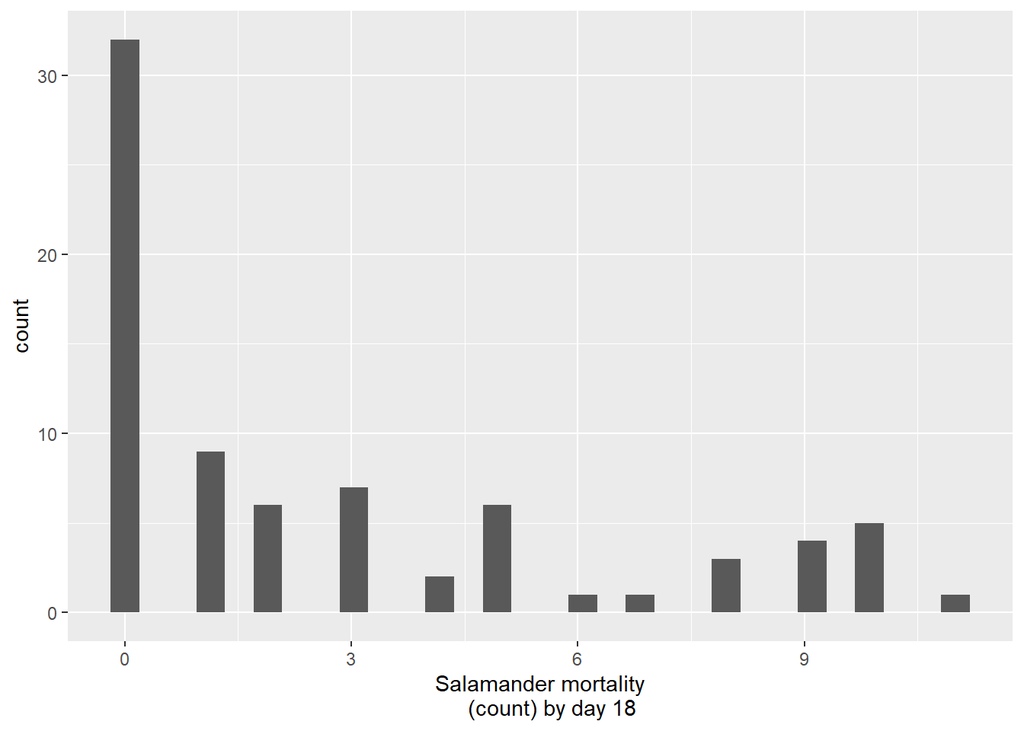

Zero-infrated test: Salamander mortality (count) by day 18

| Score | P |
| --- | --- |
| 202.49 | <0.001 |

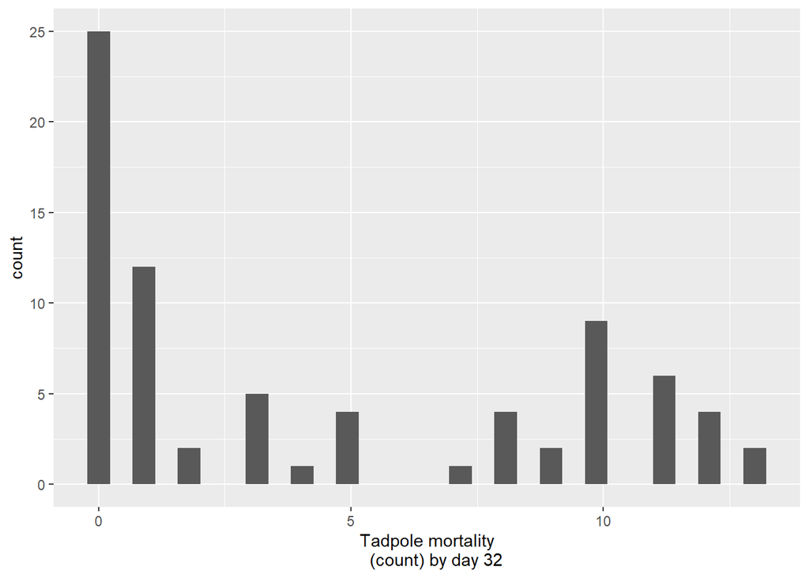

| Score | P |
| --- | --- |
| 683.92 | <0.001 |

```r
> for (sp in c("sal", "tad")) {
+
+   if (sp == "sal") {
+
+   # add ranked variable to dataframe
+   dat <- timeser.dat %>%
+     filter(Period == 2) %>%
+     .[, "Mort.sal"] %>%
+     as.data.frame()
+
+   } else {
+
+   # add ranked variable to dataframe
+   dat <- timeser.dat %>%
+     filter(Period == 4) %>%
+     .[, "Mort.sal"] %>%
+     as.data.frame()
+
+   }
+
+   hist <- ggplot(dat, aes(x = dat[, 1])) +
+     geom_histogram() +
+     xlab(cap[sp,])
+
+   print(hist)
+
+   #+++++++++++++++++++++++++++++++++++++++++++#
+   # Zero-infration test
+   #+++++++++++++++++++++++++++++++++++++++++++#
+   lambda_est <- mean(dat[, 1])
+   p0_tilde <- exp(-lambda_est)
+   n0 <- sum(dat[, 1] == 0, na.rm=TRUE)
+   n <- length(dat[, 1])
+   # JVDB score test
+   # `n*p0_tilde` : number of observtions 'expected' to be zero
+   numerator   <- (n0 -n*p0_tilde)^2
+   denominator <- n*p0_tilde*(1-p0_tilde) - n*lambda_est*(p0_tilde^2)
+   test_stat   <- numerator / denominator
+   pvalue      <- pchisq(test_stat,df=1, ncp=0, lower.tail=FALSE)
+   tibble(
+     'Score' = test_stat %>%
+       round(2),
+     'Pval' = pvalue
+     ) %>%
+     mutate_at(-1, as.numeric) %>%
+     mutate_at("Pval", round, 3) %>%
+     mutate(P = ifelse(Pval == 0, "<0.001", Pval)) %>%
+     dplyr::select(-Pval) %>%
+     kable("html", caption = paste("Zero-infrated test:", cap[sp,])) %>%
+     kable_styling("striped", position = "left") %>%
+     print()
+
+ }
```

## Scheirer-Ray-Hare test

We use Scheirer-Ray-Hare (SRH) test, which extends the Kruskall-Wallis test to consider interactions between factors.

**Treat** : Full factorial treatment for Initial size, and salamander and tadpole population identity

```r
> for (sp in c("sal", "tad")) {
+
+   if (sp == "sal") {
+
+   # add ranked variable to dataframe
+   dat <- timeser.dat %>%
+     filter(Period == 2)
+
+   p <- ggplot(dat, aes(x = Treat, y = Mort.sal))
+
+   } else {
+
+   # add ranked variable to dataframe
+   dat <- timeser.dat %>%
+     filter(Period == 4)
+
+   p <- ggplot(dat, aes(x = Treat, y = Mort.tad))
+
+   }
+
+    p2 <- p +
+     geom_boxplot(aes(colour = SalxTad), outlier.shape = NA) +
+     geom_point(
+       mapping = aes(shape = HatchTiming, colour = SalxTad),
+       position = position_jitter(width = 0.3, height = 0),
+       alpha = 0.8, size = 2.3
+       ) +
+      labs(
+        y = cap[sp,],
+        x = "Initial size distribution x
+ Salamander population x Tadpole population",
+        colour =
+        "Salamander x
+ Tadpole
+ population pair"
+      ) +
+     mytheme
+
+   #+++++++++++++++++++++++++++++++++++++++++++++++#
+   # Full model including interaction terms
+   #+++++++++++++++++++++++++++++++++++++++++++++++#
+   dat$rank <- rank(dat[, paste0("Mort.",sp)])
+
+   srh_res <- SRH_fun(aov(rank ~ Size * Sal * Tad, data = dat))$SRH.out.table
+   srh_res %>%
+     kable("html", 4, caption = paste("SRH:", cap[sp,])) %>%
+     kable_styling("striped", position = "left") %>%
+     print
+
+   #+++++++++++++++++++++++++++++++++++++++++++++#
+   # If ANOVA is (marginally) significant
+   #+++++++++++++++++++++++++++++++++++++++++++++#
+   if (srh_res$P < 0.06) {
+
+     # Tukey
+     Tukey.group <- HSD.test(
+         aov(rank ~ Treat, data = dat),
+         "Treat", group = TRUE
+       )$groups %>% dplyr::select(groups) %>%
+         mutate(Treat = rownames(.))
+
+     # Tukey
+     TukeyHSD(
+         aov(rank ~ Treat, data = dat),
+         "Treat", group = TRUE
+       )$Treat %>%
+       as.data.frame %>%
+       rownames_to_column("Comp") %>%
+       dplyr::select("Comp", "p adj") %>%
+       kable("html", digits = 4, caption = paste("Tukey:", sp)) %>%
+       kable_styling("striped", position = "left")  %>%
+       scroll_box(width = "100%", height = "350px") %>%
+       print()
+
+
+      p3 <- p2 +
+       geom_text(
+         data = Tukey.group,
+         aes(x = Treat, y = max(dat[, paste0("Mort.",sp)])*1.1, label = groups)
+         )
+
+   #+++++++++++++++++++++++++++++++++++++++++++++#
+   # If ANOVA is non-significant
+   #+++++++++++++++++++++++++++++++++++++++++++++#
+   } else {
+
+     p3 <- p2
+
+   }
+
+   assign(paste0("p.", sp), p3)
+
+ }
```

SRH: Salamander mortality (count) by day 18

Factor

Df

SRH

P

Significance

Size

1

35.1471

0.0000

Sal

1

3.2842

0.0700

Tad

1

0.6747

0.4114

Size:Sal

1

8.2970

0.0040

Size:Tad

1

0.1004

0.7513

Sal:Tad

1

0.1041

0.7470

Size:Sal:Tad

1

0.0064

0.9364

Tukey: sal

| Comp | p adj |
| --- | --- |
| Hetero Chitose Erimo-Hetero Chitose Chitose | 1.0000 |
| Hetero Erimo Chitose-Hetero Chitose Chitose | 0.0314 |
| Hetero Erimo Erimo-Hetero Chitose Chitose | 0.0034 |
| Homo Chitose Chitose-Hetero Chitose Chitose | 0.1733 |
| Homo Chitose Erimo-Hetero Chitose Chitose | 0.3961 |
| Homo Erimo Chitose-Hetero Chitose Chitose | 0.0065 |
| Homo Erimo Erimo-Hetero Chitose Chitose | 0.1048 |
| Hetero Erimo Chitose-Hetero Chitose Erimo | 0.0314 |
| Hetero Erimo Erimo-Hetero Chitose Erimo | 0.0034 |
| Homo Chitose Chitose-Hetero Chitose Erimo | 0.1733 |
| Homo Chitose Erimo-Hetero Chitose Erimo | 0.3961 |
| Homo Erimo Chitose-Hetero Chitose Erimo | 0.0065 |
| Homo Erimo Erimo-Hetero Chitose Erimo | 0.1048 |
| Hetero Erimo Erimo-Hetero Erimo Chitose | 0.9985 |
| Homo Chitose Chitose-Hetero Erimo Chitose | 0.0000 |
| Homo Chitose Erimo-Hetero Erimo Chitose | 0.0000 |
| Homo Erimo Chitose-Hetero Erimo Chitose | 0.0000 |
| Homo Erimo Erimo-Hetero Erimo Chitose | 0.0000 |
| Homo Chitose Chitose-Hetero Erimo Erimo | 0.0000 |
| Homo Chitose Erimo-Hetero Erimo Erimo | 0.0000 |
| Homo Erimo Chitose-Hetero Erimo Erimo | 0.0000 |
| Homo Erimo Erimo-Hetero Erimo Erimo | 0.0000 |
| Homo Chitose Erimo-Homo Chitose Chitose | 0.9990 |
| Homo Erimo Chitose-Homo Chitose Chitose | 0.9722 |
| Homo Erimo Erimo-Homo Chitose Chitose | 1.0000 |
| Homo Erimo Chitose-Homo Chitose Erimo | 0.7015 |
| Homo Erimo Erimo-Homo Chitose Erimo | 0.9973 |
| Homo Erimo Erimo-Homo Erimo Chitose | 0.9734 |

SRH: Tadpole mortality (count) by day 32

Factor

Df

SRH

P

Significance

Size

1

14.0689

0.0002

Sal

1

24.8481

0.0000

Tad

1

0.0001

0.9940

Size:Sal

1

8.4196

0.0037

Size:Tad

1

0.6525

0.4192

Sal:Tad

1

0.0591

0.8079

Size:Sal:Tad

1

0.0572

0.8110

Tukey: tad

| Comp | p adj |
| --- | --- |
| Hetero Chitose Erimo-Hetero Chitose Chitose | 0.9515 |
| Hetero Erimo Chitose-Hetero Chitose Chitose | 0.0000 |
| Hetero Erimo Erimo-Hetero Chitose Chitose | 0.0000 |
| Homo Chitose Chitose-Hetero Chitose Chitose | 0.7628 |
| Homo Chitose Erimo-Hetero Chitose Chitose | 0.9515 |
| Homo Erimo Chitose-Hetero Chitose Chitose | 1.0000 |
| Homo Erimo Erimo-Hetero Chitose Chitose | 0.9992 |
| Hetero Erimo Chitose-Hetero Chitose Erimo | 0.0000 |
| Hetero Erimo Erimo-Hetero Chitose Erimo | 0.0000 |
| Homo Chitose Chitose-Hetero Chitose Erimo | 0.9995 |
| Homo Chitose Erimo-Hetero Chitose Erimo | 1.0000 |
| Homo Erimo Chitose-Hetero Chitose Erimo | 0.9515 |
| Homo Erimo Erimo-Hetero Chitose Erimo | 0.7052 |
| Hetero Erimo Erimo-Hetero Erimo Chitose | 1.0000 |
| Homo Chitose Chitose-Hetero Erimo Chitose | 0.0000 |
| Homo Chitose Erimo-Hetero Erimo Chitose | 0.0000 |
| Homo Erimo Chitose-Hetero Erimo Chitose | 0.0000 |
| Homo Erimo Erimo-Hetero Erimo Chitose | 0.0000 |
| Homo Chitose Chitose-Hetero Erimo Erimo | 0.0000 |
| Homo Chitose Erimo-Hetero Erimo Erimo | 0.0000 |
| Homo Erimo Chitose-Hetero Erimo Erimo | 0.0000 |
| Homo Erimo Erimo-Hetero Erimo Erimo | 0.0001 |
| Homo Chitose Erimo-Homo Chitose Chitose | 0.9995 |
| Homo Erimo Chitose-Homo Chitose Chitose | 0.7628 |
| Homo Erimo Erimo-Homo Chitose Chitose | 0.4246 |
| Homo Erimo Chitose-Homo Chitose Erimo | 0.9515 |
| Homo Erimo Erimo-Homo Chitose Erimo | 0.7052 |
| Homo Erimo Erimo-Homo Erimo Chitose | 0.9992 |

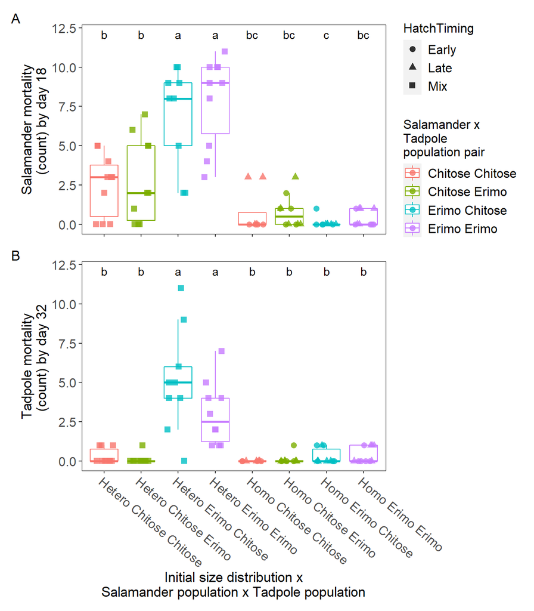

```r
> p.sal*
+   theme(
+     axis.text.x = element_blank(),
+     axis.title.x = element_blank()
+     ) +
+   p.tad*
+     theme(
+     legend.position = 'none',
+     ) +
+   plot_layout(ncol = 1) +
+   plot_annotation(tag_levels = 'A')
```

# Salamander morphology

### Original data description

**ID** : Tank ID

**Size** : Initial salamander size distribution.

- *Homo*, homogenous - suppressing salamander cannibalism
- *Hetero*, heterogenous - facilitating salamander cannibalism

**Sal** : Salamander geographic population identity

**Tad** : Tadpole geographic population identity

**Hatchtiming** : Salamander hatch timing conditions.

- *mix*, initial size heterogenous treatment
- *early*, early hatch timing sub-treatment of initial size homogenous treatment
- *late*, late hatch timing sub-treatment of initial size homogenous treatment

**[Trait name]**_**[individual ID]** : Trait measurement of largest 4 individuals at each tank

Trait name

- *HeadWidth* : not used in the analysis
- *JawWidth* : used as *Gape width* later
- *HeadLength* : not used in the analysis
- *BodyLength* : used as *Trunk length* later
- *TailLength* : not used in the analysis

```r
> dat.sal <- read.xlsx("./Data.xlsx", sheet = "Sal.morph.day18") %>%
+   mutate_at(vars(1:5), as.factor)
>
> dat.sal %>%
+   kable("html") %>% kable_styling("striped", position = "left") %>%
+   scroll_box(width = "100%", height = "300px")
```

| ID | Size | Tad | Sal | HatchTiming | HeadWidth_1 | JawWidth_1 | HeadLength_1 | BodyLength_1 | TailLength_1 | HeadWidth_2 | JawWidth_2 | HeadLength_2 | BodyLength_2 | TailLength_2 | HeadWidth_3 | JawWidth_3 | HeadLength_3 | BodyLength_3 | TailLength_3 | HeadWidth_4 | JawWidth_4 | HeadLength_4 | BodyLength_4 | TailLength_4 |
| --- | --- | --- | --- | --- | --- | --- | --- | --- | --- | --- | --- | --- | --- | --- | --- | --- | --- | --- | --- | --- | --- | --- | --- | --- |
| 1 | Hetero | Erimo | Erimo | Mix | 10.668522 | 10.245649 | 11.277889 | 11.476379 | 21.346886 | 9.871014 | 9.286950 | 9.416587 | 9.451563 | 18.162685 | 8.805742 | 8.138379 | 9.574610 | 9.294511 | 21.08939 | 8.628415 | 6.537534 | 7.745750 | 7.223315 | 11.42700 |
| 2 | Hetero | Erimo | Erimo | Mix | 10.959000 | 9.413000 | 8.402000 | 10.051000 | 22.031000 | 9.590000 | 8.637000 | 7.265000 | 10.700000 | 15.420000 | 8.848000 | 6.902000 | 6.317000 | 9.124000 | 19.40100 | 6.622000 | 4.852000 | 5.947000 | 7.009000 | 15.08600 |
| 3 | Hetero | Erimo | Erimo | Mix | 11.462056 | 9.619630 | 8.453043 | 12.228718 | 17.892128 | 10.393040 | 8.593306 | 8.863710 | 8.980630 | 22.014777 | 9.917646 | 7.314824 | 8.201299 | 10.542186 | 16.78903 | 10.334373 | 8.291571 | 7.585642 | 11.302926 | 17.56994 |
| 4 | Hetero | Erimo | Erimo | Mix | 10.790000 | 9.454000 | 9.365000 | 8.010000 | 23.814000 | 10.620000 | 9.013000 | 8.733000 | 9.144000 | 19.966000 | 10.590000 | 9.207000 | 8.668000 | 9.039000 | 20.52100 | 10.114000 | 8.608000 | 8.497000 | 6.658000 | 20.16400 |
| 5 | Hetero | Erimo | Erimo | Mix | 10.881000 | 10.128000 | 9.253000 | 10.496000 | 20.818000 | 9.745000 | 8.610000 | 8.315000 | 9.611000 | 18.670000 | 8.129000 | 6.933000 | 7.108000 | 8.575000 | 17.81600 | 7.907000 | 6.000000 | 7.132000 | 9.262000 | 16.90100 |
| 6 | Hetero | Erimo | Erimo | Mix | 11.828000 | 10.195000 | 8.528000 | 11.362000 | 18.318000 | 11.777000 | 10.230000 | 8.920000 | 10.761000 | 19.485000 | 11.258000 | 9.284000 | 8.417000 | 12.434000 | 16.01700 | 10.068000 | 8.976000 | 8.447000 | 10.391000 | 19.32800 |
| 7 | Hetero | Erimo | Erimo | Mix | 10.242000 | 9.354000 | 8.233000 | 8.876000 | 22.983000 | 11.656000 | 9.868000 | 8.696000 | 10.303000 | 18.973000 | 10.292000 | 9.033000 | 7.985000 | 8.205000 | 20.09300 | 10.576000 | 8.933000 | 8.698000 | 9.997000 | 19.79200 |
| 8 | Hetero | Erimo | Erimo | Mix | 13.251000 | 11.618000 | 10.238000 | 12.263000 | 23.242000 | 11.929000 | 11.073000 | 9.823000 | 12.398000 | 20.825000 | 11.549000 | 10.460000 | 9.466000 | 10.438000 | 21.94800 | 11.497000 | 10.782000 | 9.211000 | 11.163000 | 21.63000 |
| 9 | Hetero | Erimo | Erimo | Mix | 11.569000 | 10.311000 | 10.611000 | 13.485000 | 21.115000 | 12.179000 | 10.579000 | 10.126000 | 12.066000 | 21.717000 | 11.142000 | 9.469000 | 9.703000 | 11.438000 | 21.40300 | 11.179000 | 9.411000 | 9.825000 | 10.409000 | 19.99300 |
| 10 | Hetero | Erimo | Erimo | Mix | 9.760000 | 8.563000 | 8.690000 | 11.383000 | 19.027000 | 9.542000 | 8.396000 | 7.961000 | 8.970000 | 18.878000 | 8.871000 | 7.415000 | 7.032000 | 8.616000 | 19.75600 | 7.913000 | 6.136000 | 6.423000 | 7.595000 | 14.85000 |
| 11 | Hetero | Erimo | Chitose | Mix | 8.465000 | 7.377000 | 7.518000 | 8.968000 | 18.947000 | 8.064000 | 7.101000 | 7.292000 | 7.330000 | 17.261000 | 7.222000 | 5.850000 | 6.679000 | 6.932000 | 16.43700 | 5.745000 | 4.631000 | 5.492000 | 5.973000 | 12.11900 |
| 12 | Hetero | Erimo | Chitose | Mix | 8.863000 | 7.921000 | 7.279000 | 9.168000 | 19.748000 | 5.338000 | 4.071000 | 4.476000 | 4.995000 | 12.009000 | 6.220000 | 4.745000 | 5.525000 | 7.787000 | 12.60400 | 5.131000 | 4.011000 | 5.247000 | 5.993000 | 12.34300 |
| 13 | Hetero | Erimo | Chitose | Mix | 7.465000 | 6.171000 | 7.005000 | 7.395000 | 16.186000 | 6.204000 | 4.833000 | 5.008000 | 6.321000 | 13.922000 | 7.083000 | 5.391000 | 6.369000 | 8.509000 | 13.95300 | 6.275000 | 5.138000 | 5.613000 | 6.871000 | 13.48900 |
| 14 | Hetero | Erimo | Chitose | Mix | 6.978000 | 5.847000 | 6.788000 | 8.625000 | 16.684000 | 5.861000 | 4.052000 | 4.949000 | 5.837000 | 11.697000 | 5.753000 | 3.877000 | 5.055000 | 7.657000 | 11.19900 | 4.911000 | 3.832000 | 4.616000 | 6.434000 | 12.18100 |
| 15 | Hetero | Erimo | Chitose | Mix | 8.390000 | 7.098000 | 7.077000 | 11.212000 | 17.331000 | 7.524000 | 6.358000 | 7.043000 | 9.500000 | 15.930000 | 7.956000 | 6.571000 | 6.584000 | 8.225000 | 15.61400 | 5.921000 | 4.474000 | 5.570000 | 5.503000 | 14.51700 |
| 16 | Hetero | Erimo | Chitose | Mix | 6.778000 | 4.912000 | 6.204000 | 8.762000 | 13.468000 | 6.427000 | 5.287000 | 6.095000 | 8.762000 | 11.025000 | 5.860000 | 4.786000 | 5.702000 | 7.967000 | 12.65400 | 6.325000 | 4.845000 | 5.692000 | 7.782000 | 13.36100 |
| 17 | Hetero | Erimo | Chitose | Mix | 6.820000 | 5.508000 | 6.844000 | 8.391000 | 14.412000 | 6.349000 | 5.246000 | 6.358000 | 9.471000 | 14.522000 | 6.040000 | 4.802000 | 5.917000 | 7.232000 | 14.03700 | 5.547000 | 4.233000 | 4.640000 | 6.938000 | 12.97500 |
| 18 | Hetero | Erimo | Chitose | Mix | 4.977973 | 4.007558 | 4.803488 | 5.446962 | 12.030242 | 5.466289 | 4.484386 | 5.046024 | 7.465574 | 9.795314 | 5.575698 | 4.400319 | 4.777403 | 8.206969 | 11.62038 | 5.315524 | 4.503375 | 4.661304 | 6.818451 | 10.36033 |
| 19 | Hetero | Erimo | Chitose | Mix | 7.154000 | 5.659000 | 6.485000 | 7.097000 | 14.187000 | 6.784000 | 5.575000 | 5.791000 | 10.487000 | 10.722000 | 6.825000 | 5.031000 | 5.446000 | 9.500000 | 11.67200 | 6.263000 | 4.932000 | 5.404000 | 8.943000 | 11.70100 |
| 20 | Hetero | Erimo | Chitose | Mix | 7.580000 | 5.843000 | 6.843000 | 8.278000 | 14.042000 | 7.275000 | 5.209000 | 6.738000 | 8.062000 | 15.853000 | 6.648000 | 5.272000 | 6.275000 | 8.480000 | 14.45000 | 5.808000 | 4.394000 | 5.492000 | 7.497000 | 11.45400 |
| 21 | Hetero | Chitose | Erimo | Mix | 9.686000 | 8.294000 | 8.180000 | 9.581000 | 20.623000 | 9.153000 | 7.759000 | 7.740000 | 9.327000 | 18.045000 | 9.022000 | 6.580000 | 7.038000 | 9.139000 | 19.10500 | 8.359000 | 5.622000 | 6.345000 | 10.471000 | 15.34700 |
| 22 | Hetero | Chitose | Erimo | Mix | 10.702000 | 10.034000 | 9.182000 | 10.944000 | 23.288000 | 9.234000 | 7.623000 | 7.755000 | 8.283000 | 17.661000 | 9.709000 | 7.233000 | 7.958000 | 8.549000 | 18.86900 | 8.594000 | 6.691000 | 7.422000 | 8.036000 | 19.39700 |
| 23 | Hetero | Chitose | Erimo | Mix | 11.340000 | 10.009000 | 8.466000 | 9.050000 | 22.536000 | 10.852000 | 9.341000 | 8.783000 | 10.353000 | 19.740000 | 11.154000 | 9.466000 | 8.544000 | 9.123000 | 21.93800 | 8.971000 | 7.237000 | 7.757000 | 7.809000 | 19.34800 |
| 24 | Hetero | Chitose | Erimo | Mix | 11.544433 | 9.353091 | 8.627604 | 11.572665 | 20.712596 | 10.046516 | 8.016630 | 8.098753 | 9.302318 | 17.909240 | 8.567365 | 6.166748 | 6.860885 | 9.178832 | 15.90616 | 8.900181 | 6.640065 | 7.300827 | 9.574238 | 15.66641 |
| 25 | Hetero | Chitose | Erimo | Mix | 11.671000 | 10.384000 | 10.063000 | 11.850000 | 23.261000 | 10.322000 | 9.099000 | 8.316000 | 11.798000 | 18.946000 | 11.890000 | 10.204000 | 10.785000 | 12.414000 | 22.06400 | 10.932000 | 9.320000 | 8.582000 | 10.162000 | 22.66900 |
| 26 | Hetero | Chitose | Erimo | Mix | 11.233000 | 9.961000 | 9.265000 | 11.123000 | 19.898000 | 10.313000 | 8.411000 | 7.991000 | 10.847000 | 16.941000 | 10.392000 | 8.812000 | 7.964000 | 10.711000 | 18.47900 | 9.449000 | 7.764000 | 6.993000 | 9.349000 | 18.86500 |
| 27 | Hetero | Chitose | Erimo | Mix | 10.986000 | 8.451000 | 8.376000 | 11.937000 | 19.990000 | 11.105000 | 8.882000 | 7.966000 | 10.027000 | 20.369000 | 10.571000 | 7.912000 | 8.136000 | 10.285000 | 21.76500 | 10.492000 | 8.407000 | 7.507000 | 9.901000 | 18.09200 |
| 28 | Hetero | Chitose | Erimo | Mix | 12.759000 | 11.957000 | 10.372000 | 14.432000 | 22.362000 | 9.323000 | 7.245000 | 7.916000 | 9.025000 | 18.936000 | 9.240000 | 6.878000 | 8.230000 | 7.661000 | 21.34000 | 8.440000 | 6.396000 | 7.696000 | 9.040000 | 18.83200 |
| 30 | Hetero | Chitose | Erimo | Mix | 11.403000 | 10.314000 | 9.440000 | 12.515000 | 24.053000 | 10.076000 | 8.717000 | 8.102000 | 9.218000 | 22.953000 | 11.679000 | 9.820000 | 9.077000 | 12.250000 | 22.30000 | 9.899000 | 8.158000 | 7.898000 | 10.393000 | 18.74600 |
| 31 | Hetero | Chitose | Chitose | Mix | 8.322000 | 7.008000 | 7.075000 | 10.569000 | 14.454000 | 7.723000 | 6.603000 | 7.469000 | 10.543000 | 15.790000 | 6.302000 | 4.718000 | 6.435000 | 8.573000 | 14.14300 | 6.790000 | 4.913000 | 6.017000 | 8.115000 | 13.81700 |
| 32 | Hetero | Chitose | Chitose | Mix | 5.951000 | 4.489000 | 5.581000 | 7.454000 | 10.979000 | 5.631000 | 4.189000 | 4.544000 | 6.862000 | 11.936000 | 5.703000 | 4.062000 | 5.445000 | 7.741000 | 10.07600 | 6.196000 | 4.689000 | 5.087000 | 8.045000 | 16.30000 |
| 33 | Hetero | Chitose | Chitose | Mix | 8.850000 | 7.262000 | 7.462000 | 9.279000 | 19.715000 | 7.582000 | 6.265000 | 7.064000 | 9.164000 | 16.081000 | 7.602000 | 6.000000 | 6.708000 | 8.930000 | 13.84500 | 6.589000 | 4.786000 | 5.064000 | 8.843000 | 14.81400 |
| 34 | Hetero | Chitose | Chitose | Mix | 7.898000 | 6.675000 | 6.925000 | 8.864000 | 15.835000 | 5.937000 | 4.611000 | 5.873000 | 8.280000 | 12.804000 | 5.498000 | 4.221000 | 5.152000 | 8.003000 | 10.60900 | 5.925000 | 4.050000 | 4.463000 | 8.425000 | 10.82100 |
| 35 | Hetero | Chitose | Chitose | Mix | 7.796000 | 6.283000 | 7.061000 | 7.710000 | 16.257000 | 7.330000 | 5.750000 | 5.984000 | 8.372000 | 14.740000 | 7.459000 | 5.456000 | 5.910000 | 8.100000 | 15.60100 | 6.437000 | 4.445000 | 5.634000 | 7.409000 | 13.14200 |
| 36 | Hetero | Chitose | Chitose | Mix | 6.212000 | 4.392000 | 4.835000 | 8.826000 | 11.924000 | 5.677000 | 4.153000 | 5.271000 | 6.504000 | 10.942000 | 6.382000 | 4.602000 | 5.836000 | 7.316000 | 12.30500 | 5.740000 | 4.641000 | 4.853000 | 8.585000 | 12.47200 |
| 37 | Hetero | Chitose | Chitose | Mix | 7.500000 | 6.733000 | 5.706000 | 9.117000 | 14.510000 | 5.048000 | 3.858000 | 4.290000 | 4.674000 | 12.975000 | 4.831000 | 3.627000 | 4.543000 | 6.527000 | 10.36200 | 4.903000 | 3.901000 | 4.353000 | 6.060000 | 11.30900 |
| 38 | Hetero | Chitose | Chitose | Mix | 5.410000 | 4.077000 | 5.245000 | 7.095000 | 12.360000 | 5.552000 | 3.756000 | 4.751000 | 6.924000 | 14.303000 | 4.980000 | 3.186000 | 4.990000 | 6.240000 | 11.43900 | 4.786000 | 3.384000 | 3.986000 | 5.907000 | 11.24400 |
| 39 | Hetero | Chitose | Chitose | Mix | 8.597000 | 6.128000 | 7.387000 | 9.457000 | 14.703000 | 6.622000 | 4.971000 | 5.442000 | 8.015000 | 14.858000 | 6.382000 | 5.113000 | 6.163000 | 8.850000 | 13.54300 | 5.666000 | 4.228000 | 5.183000 | 6.190000 | 13.11000 |
| 40 | Hetero | Chitose | Chitose | Mix | 5.213000 | 4.263000 | 4.949000 | 6.169000 | 12.625000 | 5.620000 | 4.087000 | 5.194000 | 6.571000 | 12.766000 | 5.569000 | 3.919000 | 5.244000 | 8.092000 | 12.15400 | 4.592000 | 3.339000 | 4.449000 | 6.567000 | 9.88700 |
| 41 | Homo | Erimo | Erimo | Early | 8.346000 | 6.494000 | 7.021000 | 9.960000 | 16.647000 | 9.898000 | 7.789000 | 6.669000 | 8.903000 | 17.366000 | 8.963000 | 6.199000 | 7.135000 | 9.394000 | 16.11200 | 8.485000 | 6.080000 | 7.616000 | 9.490000 | 13.18100 |
| 42 | Homo | Erimo | Erimo | Early | 7.688000 | 5.971000 | 6.353000 | 7.093000 | 14.400000 | 7.236000 | 6.154000 | 5.640000 | 7.791000 | 16.388000 | 7.965000 | 5.404000 | 6.693000 | 8.020000 | 15.93500 | 8.055000 | 5.687000 | 6.842000 | 10.095000 | 13.37800 |
| 43 | Homo | Erimo | Erimo | Early | 8.365000 | 6.647000 | 7.139000 | 10.961000 | 14.097000 | 7.921000 | 5.866000 | 6.676000 | 10.385000 | 13.429000 | 7.719000 | 5.849000 | 6.413000 | 9.733000 | 14.36800 | 8.779000 | 6.825000 | 7.123000 | 9.898000 | 14.53400 |
| 44 | Homo | Erimo | Erimo | Early | 8.543000 | 6.201000 | 6.252000 | 9.126000 | 14.410000 | 8.589000 | 6.576000 | 6.325000 | 9.603000 | 15.179000 | 8.478000 | 5.904000 | 6.046000 | 9.121000 | 14.86900 | 8.310000 | 5.636000 | 6.376000 | 9.093000 | 14.55700 |
| 45 | Homo | Erimo | Erimo | Early | 10.043000 | 7.803000 | 7.626000 | 9.508000 | 15.502000 | 8.599000 | 6.706000 | 7.988000 | 8.852000 | 15.801000 | 8.657000 | 6.380000 | 6.955000 | 11.673000 | 11.31300 | 8.579000 | 5.520000 | 7.240000 | 10.416000 | 12.96200 |
| 46 | Homo | Erimo | Erimo | Late | 6.271000 | 5.409000 | 5.273000 | 7.590000 | 12.603000 | 6.573000 | 5.420000 | 6.493000 | 9.083000 | 13.012000 | 6.646000 | 4.985000 | 5.685000 | 7.584000 | 13.88200 | 6.598000 | 5.197000 | 5.734000 | 9.443000 | 12.38100 |
| 47 | Homo | Erimo | Erimo | Late | 6.706000 | 5.357000 | 5.605000 | 8.185000 | 12.960000 | 7.293000 | 5.673000 | 5.785000 | 9.757000 | 12.239000 | 7.116000 | 5.194000 | 5.778000 | 7.637000 | 12.49500 | 7.070000 | 5.300000 | 6.419000 | 8.207000 | 12.40900 |
| 48 | Homo | Erimo | Erimo | Late | 7.417000 | 6.287000 | 5.617000 | 8.890000 | 12.561000 | 7.271000 | 5.466000 | 5.906000 | 9.349000 | 13.142000 | 7.138000 | 5.423000 | 5.975000 | 9.567000 | 13.19500 | 7.077000 | 5.069000 | 6.087000 | 8.533000 | 12.60000 |
| 49 | Homo | Erimo | Erimo | Late | 8.582798 | 7.135297 | 7.202533 | 9.275673 | 13.498945 | 8.863000 | 7.810000 | 7.724000 | 10.519000 | 11.944000 | 8.821000 | 6.449000 | 6.455000 | 9.011000 | 13.77900 | 8.244000 | 6.889000 | 7.042000 | 10.481000 | 12.95900 |
| 50 | Homo | Erimo | Erimo | Late | 7.420365 | 6.101859 | 6.923531 | 9.100634 | 13.751091 | 7.558000 | 6.096000 | 6.792000 | 9.883000 | 13.867000 | 7.287000 | 5.277000 | 5.725000 | 10.285000 | 12.46500 | 7.118000 | 5.487000 | 5.509000 | 9.771000 | 12.48500 |
| 51 | Homo | Erimo | Chitose | Early | 7.219814 | 5.961349 | 6.629616 | 7.655676 | 13.864519 | 6.006616 | 4.995153 | 6.365393 | 6.137416 | 11.972886 | 5.759122 | 4.060120 | 5.254785 | 6.724661 | 11.79075 | 5.599374 | 4.098499 | 5.543118 | 7.123129 | 11.39999 |
| 52 | Homo | Erimo | Chitose | Early | 5.644000 | 4.210000 | 5.194000 | 7.630000 | 13.092000 | 4.987000 | 3.848000 | 4.422000 | 7.181000 | 11.275000 | 4.992000 | 3.710000 | 5.037000 | 7.106000 | 10.23200 | 5.736000 | 4.346000 | 5.335000 | 7.389000 | 11.02000 |
| 53 | Homo | Erimo | Chitose | Early | 5.985000 | 4.552000 | 5.806000 | 8.679000 | 12.702000 | 6.678000 | 5.270000 | 5.646000 | 8.183000 | 12.179000 | 6.241000 | 4.896000 | 5.791000 | 8.456000 | 12.13200 | 5.957000 | 4.575000 | 5.569000 | 8.222000 | 12.68100 |
| 54 | Homo | Erimo | Chitose | Early | 5.374199 | 3.839202 | 5.233644 | 7.286918 | 11.112014 | 5.615000 | 3.908000 | 4.911000 | 7.680000 | 11.090000 | 5.423000 | 3.949000 | 5.254000 | 8.930000 | 9.12500 | 5.343000 | 3.562000 | 4.536000 | 6.692000 | 10.46400 |
| 55 | Homo | Erimo | Chitose | Early | 7.698952 | 5.479098 | 6.006602 | 9.780028 | 14.655165 | 7.599000 | 5.689000 | 6.506000 | 9.285000 | 13.238000 | 6.895000 | 5.197000 | 6.399000 | 9.215000 | 12.34700 | 6.488000 | 4.840000 | 6.075000 | 9.274000 | 12.65600 |
| 56 | Homo | Erimo | Chitose | Late | 4.862556 | 3.709935 | 4.559293 | 7.110635 | 9.431961 | 4.657000 | 3.878000 | 3.817000 | 6.950000 | 9.803000 | 4.785000 | 3.507000 | 4.310000 | 7.306000 | 8.41400 | 4.891000 | 3.826000 | 4.463000 | 7.280000 | 10.04500 |
| 57 | Homo | Erimo | Chitose | Late | 5.044040 | 3.663262 | 4.734838 | 7.295320 | 9.809660 | 5.288000 | 3.825000 | 4.370000 | 7.482000 | 10.055000 | 5.031000 | 3.757000 | 4.483000 | 7.136000 | 9.45300 | 5.055000 | 3.724000 | 4.602000 | 7.313000 | 8.91400 |
| 58 | Homo | Erimo | Chitose | Late | 5.226158 | 3.854634 | 4.673971 | 6.505324 | 11.845706 | 5.164000 | 4.022000 | 4.755000 | 7.669000 | 10.571000 | 4.729000 | 3.705000 | 4.294000 | 6.860000 | 10.48200 | 5.534000 | 4.088000 | 4.427000 | 7.568000 | 9.19600 |
| 59 | Homo | Erimo | Chitose | Late | 4.788605 | 3.513405 | 4.751999 | 7.256492 | 9.877502 | 5.551000 | 4.291000 | 4.853000 | 7.364000 | 8.867000 | 4.879000 | 3.617000 | 4.548000 | 7.238000 | 9.38200 | 4.833000 | 3.476000 | 4.246000 | 7.364000 | 8.28000 |
| 60 | Homo | Erimo | Chitose | Late | 5.651247 | 3.860620 | 5.143836 | 6.608854 | 9.869948 | 5.620000 | 3.823000 | 5.062000 | 7.702000 | 9.203000 | 5.322000 | 3.586000 | 4.760000 | 7.164000 | 9.72000 | 5.111000 | 3.591000 | 4.608000 | 7.492000 | 9.47300 |
| 61 | Homo | Chitose | Erimo | Early | 9.878638 | 7.374043 | 8.413174 | 11.279348 | 12.969712 | 9.103000 | 7.090000 | 7.508000 | 10.956000 | 14.109000 | 9.185000 | 6.819000 | 6.961000 | 9.819000 | 14.94000 | 8.810000 | 6.326000 | 6.775000 | 10.730000 | 14.65500 |
| 62 | Homo | Chitose | Erimo | Early | 8.431107 | 6.404659 | 6.892538 | 9.485442 | 13.938913 | 8.519000 | 6.248000 | 7.231000 | 12.259000 | 13.065000 | 8.477000 | 6.173000 | 6.473000 | 11.265000 | 12.27100 | 8.226000 | 6.575000 | 5.844000 | 11.279000 | 12.31900 |
| 63 | Homo | Chitose | Erimo | Early | 8.457400 | 6.990130 | 6.593158 | 9.809112 | 12.652641 | 8.937000 | 6.691000 | 6.645000 | 9.845000 | 12.085000 | 7.795000 | 5.886000 | 6.434000 | 9.135000 | 12.36300 | 8.382000 | 6.271000 | 5.908000 | 8.405000 | 11.89100 |
| 64 | Homo | Chitose | Erimo | Early | 8.465261 | 7.219945 | 7.396678 | 9.510076 | 13.938170 | 8.936000 | 7.278000 | 7.430000 | 11.143000 | 14.047000 | 8.931000 | 7.155000 | 7.688000 | 10.616000 | 14.47000 | 8.503000 | 6.932000 | 7.121000 | 10.300000 | 13.52600 |
| 65 | Homo | Chitose | Erimo | Early | 9.791749 | 8.330282 | 7.230489 | 11.471728 | 13.610263 | 9.690000 | 8.584000 | 7.585000 | 12.393000 | 13.575000 | 9.479000 | 7.989000 | 7.713000 | 10.221000 | 17.10800 | 9.628000 | 8.113000 | 8.043000 | 11.867000 | 15.13500 |
| 66 | Homo | Chitose | Erimo | Late | 7.016901 | 5.281651 | 6.287385 | 10.114682 | 12.977592 | 7.045000 | 5.436000 | 6.174000 | 11.520000 | 9.584000 | 6.942000 | 5.106000 | 5.646000 | 10.194000 | 12.86400 | 7.041000 | 5.310000 | 5.771000 | 8.984000 | 12.87500 |
| 67 | Homo | Chitose | Erimo | Late | 7.810493 | 5.996442 | 6.755644 | 9.704690 | 15.168908 | 8.385000 | 7.293000 | 7.144000 | 9.485000 | 12.173000 | 7.696000 | 6.154000 | 6.202000 | 10.552000 | 10.71100 | 7.958000 | 6.055000 | 6.338000 | 9.962000 | 12.10300 |
| 68 | Homo | Chitose | Erimo | Late | 6.087324 | 4.692757 | 5.249948 | 7.972082 | 11.325782 | 6.232000 | 4.653000 | 5.305000 | 10.263000 | 10.410000 | 6.003000 | 4.243000 | 5.286000 | 8.447000 | 12.19900 | 6.064000 | 4.373000 | 5.453000 | 6.658000 | 11.82400 |
| 69 | Homo | Chitose | Erimo | Late | 7.718432 | 6.201836 | 6.288489 | 9.560028 | 13.692938 | 7.162000 | 5.272000 | 5.958000 | 13.217000 | 10.503000 | 7.686000 | 6.308000 | 5.878000 | 9.932000 | 13.68200 | 7.722000 | 5.875000 | 6.469000 | 11.026000 | 11.74000 |
| 70 | Homo | Chitose | Erimo | Late | 7.057952 | 5.426041 | 6.556888 | 8.545351 | 14.126214 | 7.139000 | 5.159000 | 6.208000 | 8.691000 | 11.922000 | 6.130000 | 4.510000 | 5.454000 | 7.423000 | 11.02100 | 6.181000 | 4.629000 | 5.791000 | 8.201000 | 11.27600 |
| 72 | Homo | Chitose | Chitose | Early | 6.001405 | 4.584525 | 5.139599 | 7.627900 | 12.514734 | 6.089000 | 4.238000 | 4.884000 | 7.642000 | 12.151000 | 6.036000 | 4.072000 | 4.938000 | 8.651000 | 10.48500 | 6.027000 | 4.325000 | 5.396000 | 8.599000 | 9.65700 |
| 73 | Homo | Chitose | Chitose | Early | 6.891000 | 6.022000 | 6.437000 | 9.373000 | 12.394000 | 7.146000 | 5.801000 | 6.417000 | 9.585000 | 10.739000 | 7.082000 | 5.720000 | 6.971000 | 8.803000 | 11.93700 | 6.579000 | 4.848000 | 5.745000 | 8.939000 | 11.17100 |
| 74 | Homo | Chitose | Chitose | Early | 8.622000 | 6.548000 | 7.166000 | 10.804000 | 11.950000 | 6.843000 | 5.098000 | 6.694000 | 9.191000 | 11.831000 | 7.556000 | 5.253000 | 5.771000 | 9.755000 | 14.17400 | 7.708000 | 5.728000 | 6.860000 | 9.414000 | 13.56500 |
| 75 | Homo | Chitose | Chitose | Early | 5.561273 | 4.134841 | 5.393974 | 7.418960 | 12.322255 | 5.778000 | 4.619000 | 5.734000 | 9.019000 | 10.641000 | 5.596000 | 4.383000 | 5.893000 | 8.131000 | 11.67900 | 5.691000 | 4.217000 | 5.331000 | 8.943000 | 9.23700 |
| 76 | Homo | Chitose | Chitose | Late | 6.083927 | 4.650300 | 5.205287 | 8.083891 | 9.976506 | 6.072000 | 4.843000 | 6.004000 | 7.278000 | 11.231000 | 6.116000 | 4.608000 | 6.092000 | 7.692000 | 10.77400 | 6.005000 | 4.327000 | 5.436000 | 8.067000 | 9.89300 |
| 77 | Homo | Chitose | Chitose | Late | 4.817769 | 3.495388 | 4.007962 | 7.676633 | 9.682969 | 4.573000 | 3.289000 | 3.990000 | 8.191000 | 9.239000 | 5.105000 | 3.940000 | 4.353000 | 7.084000 | 10.44900 | 4.851000 | 3.706000 | 4.928000 | 8.150000 | 8.15000 |
| 79 | Homo | Chitose | Chitose | Late | 4.480314 | 3.239688 | 3.687160 | 7.245246 | 8.815289 | 4.570000 | 3.350000 | 4.147000 | 7.009000 | 8.176000 | 5.467000 | 3.769000 | 5.259000 | 7.366000 | 9.75900 | 4.440000 | 3.432000 | 3.774000 | 8.080000 | 8.29200 |
| 80 | Homo | Chitose | Chitose | Late | 5.302568 | 4.320124 | 4.789066 | 8.185857 | 8.664747 | 5.397000 | 3.881000 | 4.798000 | 7.078000 | 11.068000 | 5.100000 | 3.649000 | 4.864000 | 7.924000 | 9.07500 | 5.203000 | 3.805000 | 4.675000 | 7.947000 | 9.02200 |

```r
> dat.sal %>%
+   group_by(Size, Sal, Tad) %>%
+   summarise(length(ID)) %>%
+   as.data.frame() %>%
+   rename("Replicates (N)" = "length(ID)") %>%
+   kable("html", caption = "Replications in each treatment") %>%
+   kable_styling("striped", position = "left")
```

Replications in each treatment

| Size | Sal | Tad | Replicates (N) |
| --- | --- | --- | --- |
| Hetero | Chitose | Chitose | 10 |
| Hetero | Chitose | Erimo | 10 |
| Hetero | Erimo | Chitose | 9 |
| Hetero | Erimo | Erimo | 10 |
| Homo | Chitose | Chitose | 8 |
| Homo | Chitose | Erimo | 10 |
| Homo | Erimo | Chitose | 10 |
| Homo | Erimo | Erimo | 10 |

Replications are same as used in Interaction strength.

```r
> dat.sal %<>%
+   gather(key = traitindv, value = measure, -(ID:HatchTiming)) %>%
+   mutate_if(is.character, as.factor)
>
> traitindv <- dat.sal$traitindv %>%
+   # split string by "." | into list of three columns
+   str_split(., pattern = "\\_", simplify = T, n = 2) %>%
+   unlist(.) %>%
+   as.data.frame() %>%
+   # rename colnames
+   rename(Trait = V1, Individual = V2)
>
> dat.sal.tidy <- bind_cols(dat.sal, traitindv) %>%
+   dplyr::select(-traitindv) %>%
+   mutate_at("measure", as.numeric) %>%
+   spread(key = Trait, value = measure) %>%
+   # Combine data
+   mutate(
+     SVL = HeadLength + BodyLength,
+     # HeadMorph = JawWidth / HeadWidth, # HeadMorph: measure of head morphology
+     'Relative gape width' =
+       JawWidth / BodyLength # MouthBody: measure of mouth width per body length
+     ) %>%
+   group_by(ID) %>%
+   mutate(rank.BodyLength = order(BodyLength, decreasing=TRUE)) %>%
+   ungroup() %>%
+   right_join(IDs, .) %>%
+   rename('Gape width (mm)' = JawWidth, 'Trunk length (mm)' = BodyLength) %>%
+   as.data.frame()
>
> largest.jaw <- filter(dat.sal.tidy, rank.BodyLength == 1)
> largest.jaw$Size <- factor(largest.jaw$Size,
+   levels = c("Homo", "Hetero"), ordered = TRUE
+   )
>
> largest.jaw.tidy <- largest.jaw %>%
+   dplyr::select(Size:SalxTadxHatchtiming, "Gape width (mm)", "Trunk length (mm)", "Relative gape width") %>%
+   gather(key = Trait, value = measure, -(Size:SalxTadxHatchtiming)) %>%
+   mutate_at("Trait", as.factor)
> largest.jaw.tidy$Trait <- factor(
+   largest.jaw.tidy$Trait,
+   levels = c("Gape width (mm)", "Trunk length (mm)", "Relative gape width")
+   )
>
> # To set range of plot, identify maximum trait value across treatments
> max.val <- largest.jaw.tidy %>%
+   as.data.frame() %>%
+   ungroup %>%
+   group_by(Trait) %>%
+   summarise_at("measure", max) %>%
+   `row.names<-`(., NULL) %>% # Detele existing row names
+   column_to_rownames("Trait")
```

### Analyze

**Treat** : Full factorial treatment for Initial size, and salamander and tadpole population identity

```r
> #+++++++++++++++++++++++++++++++#
> # ANOVA for each traits
> #+++++++++++++++++++++++++++++++#
>
> for (tr in levels(largest.jaw.tidy$Trait)) {
+
+   dat <- filter(largest.jaw.tidy, Trait == tr)
+
+   # ANOVA
+   anova <- summary(aov(scale(dat$measure) ~ Size*Sal*Tad, data = dat))[[1]]
+   ANOVA_stats(anova) %>%
+     kable("html", digits = 3, caption = paste(tr, "ANOVA")) %>%
+     kable_styling("striped", position = "left") %>%
+     print()
+
+   p <- ggplot(dat, aes(x = Treat, y = measure)) +
+     geom_boxplot(aes(colour = SalxTad), outlier.shape = NA) +
+     geom_point(
+       mapping = aes(shape = HatchTiming, colour = SalxTad),
+       position = position_jitter(width = 0.3, height = 0),
+       alpha = 0.8, size = 1.7
+       ) +
+      labs(
+        y = tr,
+        x = "Salamander population x Tadpole population x
+        Hatch timing",
+        colour =
+ "Salamander x
+ Tadpole
+ population pair"
+      ) +
+      labs(
+        y = tr,
+        x = "Initial size distribution x
+ Salamander population x Tadpole population",
+        colour =
+        "Salamander x
+ Tadpole
+ population pair"
+      ) +
+     mytheme
+
+   anova2 <- summary(aov(scale(dat$measure) ~ Treat, data = dat))[[1]]
+
+   #+++++++++++++++++++++++++++++++++++++++++++++#
+   # If ANOVA is (marginally) significant
+   #+++++++++++++++++++++++++++++++++++++++++++++#
+   if (anova2["Treat", "Pr(>F)"] < 0.06) {
+
+     # Tukey
+     Tukey.group <- HSD.test(
+         aov(measure ~ Treat, data = dat),
+         "Treat", group = TRUE
+       )$groups %>% dplyr::select(groups) %>%
+         mutate(Treat = rownames(.))
+
+     if (tr == "Gape width (mm)") {
+
+       p2 <- p +
+         geom_text(
+           data = Tukey.group,
+           aes(x = Treat, y = max.val["Gape width (mm)","measure"]*1.1, label = groups)
+           )
+
+     } else {
+
+       if (tr == "Body length (mm)") {
+
+         p2 <- p +
+             geom_text(
+               data = Tukey.group,
+               aes(x = Treat, y = max.val["Body length (mm)","measure"]*1.1, label = groups)
+               )
+
+       } else {
+
+         p2 <- p +
+             geom_text(
+               data = Tukey.group,
+               aes(x = Treat, y = max.val["Relative gape width","measure"]*1.1, label = groups)
+               )
+
+       }
+     }
+
+     # Tukey
+     TukeyHSD(
+         aov(measure ~ Treat, data = dat),
+         "Treat", group = TRUE
+       )$Treat %>%
+       as.data.frame %>%
+       rownames_to_column("Comp") %>%
+       dplyr::select("Comp", "p adj") %>%
+       kable("html", digits = 4, caption = paste("Tukey:", tr)) %>%
+       kable_styling("striped", position = "left")  %>%
+       scroll_box(width = "100%", height = "350px") %>%
+       print()
+
+   #+++++++++++++++++++++++++++++++++++++++++++++#
+   # If ANOVA is non-significant
+   #+++++++++++++++++++++++++++++++++++++++++++++#
+   } else {
+
+     p2 <- p
+
+   }
+
+   # print(p2)
+   assign(paste0("p.", tr), p2)
+
+ }
```

Gape width (mm) ANOVA

Factors

SS

d.f.

F

P

significance

Size

21.275

1

89.596

<0.001

Sal

32.218

1

135.683

<0.001

Tad

0.002

1

0.010

0.921

Size:Sal

5.802

1

24.434

<0.001

Size:Tad

0.293

1

1.234

0.27

Sal:Tad

0.000

1

0.001

0.978

Size:Sal:Tad

0.025

1

0.106

0.745

Residuals

16.384

69

Tukey: Gape width (mm)

| Comp | p adj |
| --- | --- |
| Hetero Chitose Erimo-Hetero Chitose Chitose | 0.9990 |
| Hetero Erimo Chitose-Hetero Chitose Chitose | 0.0000 |
| Hetero Erimo Erimo-Hetero Chitose Chitose | 0.0000 |
| Homo Chitose Chitose-Hetero Chitose Chitose | 0.7366 |
| Homo Chitose Erimo-Hetero Chitose Chitose | 0.1691 |
| Homo Erimo Chitose-Hetero Chitose Chitose | 0.8227 |
| Homo Erimo Erimo-Hetero Chitose Chitose | 0.9868 |
| Hetero Erimo Chitose-Hetero Chitose Erimo | 0.0000 |
| Hetero Erimo Erimo-Hetero Chitose Erimo | 0.0000 |
| Homo Chitose Chitose-Hetero Chitose Erimo | 0.3855 |
| Homo Chitose Erimo-Hetero Chitose Erimo | 0.0421 |
| Homo Erimo Chitose-Hetero Chitose Erimo | 0.9863 |
| Homo Erimo Erimo-Hetero Chitose Erimo | 1.0000 |
| Hetero Erimo Erimo-Hetero Erimo Chitose | 1.0000 |
| Homo Chitose Chitose-Hetero Erimo Chitose | 0.0000 |
| Homo Chitose Erimo-Hetero Erimo Chitose | 0.0000 |
| Homo Erimo Chitose-Hetero Erimo Chitose | 0.0000 |
| Homo Erimo Erimo-Hetero Erimo Chitose | 0.0000 |
| Homo Chitose Chitose-Hetero Erimo Erimo | 0.0000 |
| Homo Chitose Erimo-Hetero Erimo Erimo | 0.0000 |
| Homo Erimo Chitose-Hetero Erimo Erimo | 0.0000 |
| Homo Erimo Erimo-Hetero Erimo Erimo | 0.0000 |
| Homo Chitose Erimo-Homo Chitose Chitose | 0.9898 |
| Homo Erimo Chitose-Homo Chitose Chitose | 0.0688 |
| Homo Erimo Erimo-Homo Chitose Chitose | 0.2341 |
| Homo Erimo Chitose-Homo Chitose Erimo | 0.0029 |
| Homo Erimo Erimo-Homo Chitose Erimo | 0.0179 |
| Homo Erimo Erimo-Homo Erimo Chitose | 0.9990 |

Trunk length (mm) ANOVA

Factors

SS

d.f.

F

P

significance

Size

3.925

1

6.976

0.01

Sal

30.254

1

53.773

<0.001

Tad

0.874

1

1.554

0.217

Size:Sal

1.588

1

2.822

0.098

Size:Tad

0.348

1

0.618

0.434

Sal:Tad

0.080

1

0.142

0.707

Size:Sal:Tad

0.110

1

0.196

0.659

Residuals

38.821

69

Tukey: Trunk length (mm)

| Comp | p adj |
| --- | --- |
| Hetero Chitose Erimo-Hetero Chitose Chitose | 1.0000 |
| Hetero Erimo Chitose-Hetero Chitose Chitose | 0.0002 |
| Hetero Erimo Erimo-Hetero Chitose Chitose | 0.0014 |
| Homo Chitose Chitose-Hetero Chitose Chitose | 1.0000 |
| Homo Chitose Erimo-Hetero Chitose Chitose | 0.9582 |
| Homo Erimo Chitose-Hetero Chitose Chitose | 0.1034 |
| Homo Erimo Erimo-Hetero Chitose Chitose | 0.6286 |
| Hetero Erimo Chitose-Hetero Chitose Erimo | 0.0003 |
| Hetero Erimo Erimo-Hetero Chitose Erimo | 0.0022 |
| Homo Chitose Chitose-Hetero Chitose Erimo | 1.0000 |
| Homo Chitose Erimo-Hetero Chitose Erimo | 0.9257 |
| Homo Erimo Chitose-Hetero Chitose Erimo | 0.1385 |
| Homo Erimo Erimo-Hetero Chitose Erimo | 0.7111 |
| Hetero Erimo Erimo-Hetero Erimo Chitose | 0.9972 |
| Homo Chitose Chitose-Hetero Erimo Chitose | 0.0005 |
| Homo Chitose Erimo-Hetero Erimo Chitose | 0.0000 |
| Homo Erimo Chitose-Hetero Erimo Chitose | 0.4244 |
| Homo Erimo Erimo-Hetero Erimo Chitose | 0.0512 |
| Homo Chitose Chitose-Hetero Erimo Erimo | 0.0036 |
| Homo Chitose Erimo-Hetero Erimo Erimo | 0.0000 |
| Homo Erimo Chitose-Hetero Erimo Erimo | 0.8271 |
| Homo Erimo Erimo-Hetero Erimo Erimo | 0.2128 |
| Homo Chitose Erimo-Homo Chitose Chitose | 0.9639 |
| Homo Erimo Chitose-Homo Chitose Chitose | 0.1599 |
| Homo Erimo Erimo-Homo Chitose Chitose | 0.7152 |
| Homo Erimo Chitose-Homo Chitose Erimo | 0.0049 |
| Homo Erimo Erimo-Homo Chitose Erimo | 0.0941 |
| Homo Erimo Erimo-Homo Erimo Chitose | 0.9658 |

Relative gape width ANOVA

Factors

SS

d.f.

F

P

significance

Size

26.985

1

71.170

<0.001

Sal

17.891

1

47.186

<0.001

Tad

0.581

1

1.534

0.22

Size:Sal

4.047

1

10.675

0.002

Size:Tad

0.277

1

0.731

0.396

Sal:Tad

0.048

1

0.126

0.723

Size:Sal:Tad

0.008

1

0.020

0.888

Residuals

26.162

69

Tukey: Relative gape width

| Comp | p adj |
| --- | --- |
| Hetero Chitose Erimo-Hetero Chitose Chitose | 0.9864 |
| Hetero Erimo Chitose-Hetero Chitose Chitose | 0.0002 |
| Hetero Erimo Erimo-Hetero Chitose Chitose | 0.0000 |
| Homo Chitose Chitose-Hetero Chitose Chitose | 0.4440 |
| Homo Chitose Erimo-Hetero Chitose Chitose | 0.2847 |
| Homo Erimo Chitose-Hetero Chitose Chitose | 0.9975 |
| Homo Erimo Erimo-Hetero Chitose Chitose | 1.0000 |
| Hetero Erimo Chitose-Hetero Chitose Erimo | 0.0033 |
| Hetero Erimo Erimo-Hetero Chitose Erimo | 0.0000 |
| Homo Chitose Chitose-Hetero Chitose Erimo | 0.0872 |
| Homo Chitose Erimo-Hetero Chitose Erimo | 0.0377 |
| Homo Erimo Chitose-Hetero Chitose Erimo | 0.7740 |
| Homo Erimo Erimo-Hetero Chitose Erimo | 0.9305 |
| Hetero Erimo Erimo-Hetero Erimo Chitose | 0.9594 |
| Homo Chitose Chitose-Hetero Erimo Chitose | 0.0000 |
| Homo Chitose Erimo-Hetero Erimo Chitose | 0.0000 |
| Homo Erimo Chitose-Hetero Erimo Chitose | 0.0000 |
| Homo Erimo Erimo-Hetero Erimo Chitose | 0.0001 |
| Homo Chitose Chitose-Hetero Erimo Erimo | 0.0000 |
| Homo Chitose Erimo-Hetero Erimo Erimo | 0.0000 |
| Homo Erimo Chitose-Hetero Erimo Erimo | 0.0000 |
| Homo Erimo Erimo-Hetero Erimo Erimo | 0.0000 |
| Homo Chitose Erimo-Homo Chitose Chitose | 1.0000 |
| Homo Erimo Chitose-Homo Chitose Chitose | 0.8363 |
| Homo Erimo Erimo-Homo Chitose Chitose | 0.6367 |
| Homo Erimo Chitose-Homo Chitose Erimo | 0.7028 |
| Homo Erimo Erimo-Homo Chitose Erimo | 0.4661 |
| Homo Erimo Erimo-Homo Erimo Chitose | 1.0000 |

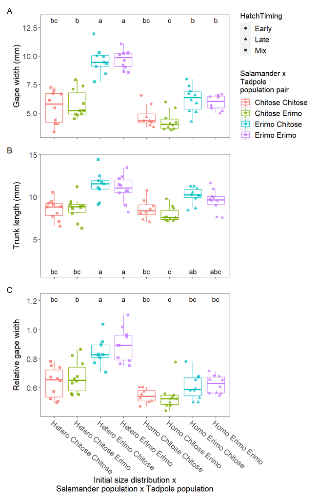

```r
> #+++++++++++++++++++++++++++++++#
> # Plot
> #+++++++++++++++++++++++++++++++#
> (`p.Gape width (mm)` +
+     `p.Trunk length (mm)`*
+      theme(legend.position = 'none')
+   )*
+   theme(
+     axis.text.x = element_blank(),
+     axis.title.x = element_blank()
+     ) +
+   `p.Relative gape width`*
+      theme(legend.position = 'none') +
+   plot_layout(ncol = 1) +
+   plot_annotation(tag_levels = 'A')
```

```r
> largest.jaw %>%
+   group_by(Treat) %>%
+   summarise(N = length(ID)) %>%
+   kable("html", caption = "Sample size") %>%
+   kable_styling("striped", position = "left")
```

Sample size

| Treat | N |
| --- | --- |
| Hetero Chitose Chitose | 10 |
| Hetero Chitose Erimo | 10 |
| Hetero Erimo Chitose | 9 |
| Hetero Erimo Erimo | 10 |
| Homo Chitose Chitose | 8 |
| Homo Chitose Erimo | 10 |
| Homo Erimo Chitose | 10 |
| Homo Erimo Erimo | 10 |

# Tadpole morphology

### Original data description

**ID** : Tank ID

**Size** : Initial salamander size distribution.

- *Homo*, homogenous - suppressing salamander cannibalism
- *Hetero*, heterogenous - facilitating salamander cannibalism

**Sal** : Salamander geographic population identity

**Tad** : Tadpole geographic population identity

**Hatchtiming** : Salamander hatch timing conditions.

- *mix*, initial size heterogenous treatment
- *early*, early hatch timing sub-treatment of initial size homogenous treatment
- *late*, late hatch timing sub-treatment of initial size homogenous treatment

**Individual** : ID of measured inditivual

**[Trait name].(mm)** : Trait measurement (mm)

- *Body.Length*
- *Body.Width*

```r
> dat.tad <- read.xlsx(
+   "./Data.xlsx", sheet = "Tad.morph.day18"
+   )
>
> dat.tad %>%
+   kable("html") %>% kable_styling("striped", position = "left") %>%
+   scroll_box(width = "100%", height = "500px")
```

| ID | Size | Sal | Tad | HatchTiming | Individual | Body.width.(mm) | Body.length.(mm) |
| --- | --- | --- | --- | --- | --- | --- | --- |
| 1 | Hetero | Erimo | Erimo | Mix | 1 | 10.425956 |  |
| 1 | Hetero | Erimo | Erimo | Mix | 2 | 10.042897 | 14.35781 |
| 1 | Hetero | Erimo | Erimo | Mix | 3 |  | 14.00728 |
| 1 | Hetero | Erimo | Erimo | Mix | 4 | 9.131851 | 14.25978 |
| 1 | Hetero | Erimo | Erimo | Mix | 5 | 9.094677 | 13.21880 |
| 1 | Hetero | Erimo | Erimo | Mix | 6 | 9.163941 | 13.39021 |
| 1 | Hetero | Erimo | Erimo | Mix | 7 | 10.029307 | 13.32594 |
| 1 | Hetero | Erimo | Erimo | Mix | 8 | 9.759702 | 13.80483 |
| 1 | Hetero | Erimo | Erimo | Mix | 9 | 9.833701 | 14.45583 |
| 1 | Hetero | Erimo | Erimo | Mix | 10 | 9.981611 | 14.27513 |
| 1 | Hetero | Erimo | Erimo | Mix | 11 | 8.946065 | 12.94402 |
| 1 | Hetero | Erimo | Erimo | Mix | 12 | 9.554013 | 13.89733 |
| 1 | Hetero | Erimo | Erimo | Mix | 13 | 10.425956 | 13.76730 |
| 1 | Hetero | Erimo | Erimo | Mix | 14 | 10.540812 | 15.37213 |
| 1 | Hetero | Erimo | Erimo | Mix | 15 | 9.021818 | 12.48460 |
| 2 | Hetero | Erimo | Erimo | Mix | 1 | 10.529196 | 13.58941 |
| 2 | Hetero | Erimo | Erimo | Mix | 2 | 10.529196 | 14.34367 |
| 2 | Hetero | Erimo | Erimo | Mix | 3 | 9.376368 | 13.52595 |
| 2 | Hetero | Erimo | Erimo | Mix | 4 | 9.788896 | 12.68814 |
| 2 | Hetero | Erimo | Erimo | Mix | 5 | 9.696910 | 13.46549 |
| 2 | Hetero | Erimo | Erimo | Mix | 6 | 9.657144 | 13.78332 |
| 2 | Hetero | Erimo | Erimo | Mix | 7 | 9.747623 | 12.03560 |
| 2 | Hetero | Erimo | Erimo | Mix | 8 | 9.723723 | 12.41178 |
| 2 | Hetero | Erimo | Erimo | Mix | 9 | 10.517246 | 13.74095 |
| 2 | Hetero | Erimo | Erimo | Mix | 10 | 9.952380 | 13.97704 |
| 2 | Hetero | Erimo | Erimo | Mix | 11 | 10.375753 | 14.34729 |
| 2 | Hetero | Erimo | Erimo | Mix | 12 | 10.619072 | 14.40623 |
| 3 | Hetero | Erimo | Erimo | Mix | 1 | 10.165026 | 14.31051 |
| 3 | Hetero | Erimo | Erimo | Mix | 2 | 10.363665 | 14.88510 |
| 3 | Hetero | Erimo | Erimo | Mix | 3 | 10.088033 | 14.83829 |

[output cut: 640 more lines]

```r
> dat.tad %>%
+   drop_na() %>%
+   group_by(Size, Sal, Tad) %>%
+   summarise(length(unique(ID))) %>%
+   as.data.frame() %>%
+   rename("Replicates (N)" = "length(unique(ID))") %>%
+   kable("html", caption = "**Table S1. Replicates assessed for
+ tadpole morphology.** From the tanks assessed for interaction strength, 11 tanks were excluded when assessing tadpole morphology because tadpoles were moving or inclining in the photographs.") %>%
+   kable_styling("striped", position = "left")
```

**Table S1. Replicates assessed for tadpole morphology.** From the tanks assessed for interaction strength, 11 tanks were excluded when assessing tadpole morphology because tadpoles were moving or inclining in the photographs.

| Size | Sal | Tad | Replicates (N) |
| --- | --- | --- | --- |
| Hetero | Chitose | Chitose | 9 |
| Hetero | Chitose | Erimo | 9 |
| Hetero | Erimo | Chitose | 8 |
| Hetero | Erimo | Erimo | 10 |
| Homo | Chitose | Chitose | 6 |
| Homo | Chitose | Erimo | 9 |
| Homo | Erimo | Chitose | 7 |
| Homo | Erimo | Erimo | 8 |

```r
> dat.tad %<>% mutate_at("ID", as.factor) %>%
+   left_join(IDs) %>%
+   arrange(ID, Individual) %>%
+   drop_na(Treat) %>%
+   mutate(
+     'Relative body width' = `Body.width.(mm)`/`Body.length.(mm)`
+   ) %>%
+   mutate_at(vars(ID:Individual), as.factor) %>%
+   drop_na(contains("Length"), contains("Width"))
> dat.tad$Size <- factor(dat.tad$Size,
+   levels = c("Homo", "Hetero"), ordered = TRUE
+   )
>
> #++++++++++++++++++++++++++++++++++#
> # Mean of each tanks : dat.tad.sum
> #++++++++++++++++++++++++++++++++++#
> dat.tad.sum <- dat.tad %>%
+   group_by(ID) %>%
+   summarise_if(
+     is.numeric,
+     funs(mean(., na.rm = TRUE), sd(., na.rm = TRUE), length(.))
+     ) %>%
+   ungroup(.) %>%
+   as.data.frame() %>%
+   dplyr::select(ID, contains("mean"), -contains("scale")) %>%
+   gather(key = Trait, value = measure, -ID) %>%
+   mutate_at(c("Trait", "ID"), as.factor) %>%
+   left_join(IDs)
> levels(dat.tad.sum$Trait) <- c(
+   "Body length (mm)", "Body width (mm)", "Relative body width"
+   ) #, "Relative body width log"
> dat.tad.sum$Trait <- factor(
+   dat.tad.sum$Trait,
+   levels = c("Body width (mm)", "Body length (mm)", "Relative body width"
+              )#, "Relative body width log"
+   )
>
> # To set range of plot, identify maximum trait value across treatments
> max.val <- dat.tad.sum %>%
+   ungroup %>%
+   group_by(Trait) %>%
+   summarise_at("measure", max) %>%
+   `row.names<-`(., NULL) %>%
+   column_to_rownames("Trait")
```

### Analyze

**Treat** : Full factorial treatment for Initial size, and salamander and tadpole population identity

```r
> #++++++++++++++++++++++++++++++++#
> # Analyses
> #++++++++++++++++++++++++++++++++#
>
> for (tr in levels(dat.tad.sum$Trait)) {
+
+   dat <- filter(dat.tad.sum, Trait == tr)
+
+   # ANOVA
+   anova <- summary(aov(scale(dat$measure) ~ Size*Sal*Tad, data = dat))[[1]]
+   ANOVA_stats(anova) %>%
+     kable("html", digits = 3, caption = paste(tr, "ANOVA")) %>%
+     kable_styling("striped", position = "left") %>%
+     print()
+
+   p <- ggplot(dat, aes(x = Treat, y = measure)) +
+     geom_boxplot(aes(colour = SalxTad), outlier.shape = NA) +
+     geom_point(
+       mapping = aes(shape = HatchTiming, colour = SalxTad),
+       position = position_jitter(width = 0.3, height = 0),
+       alpha = 0.8, size = 1.7
+       ) +
+      labs(
+        y = tr,
+        x = "Salamander population x Tadpole population x
+        Hatch timing",
+        colour =
+        "Salamander x
+ Tadpole
+ population pair"
+      ) +
+      labs(
+        y = tr,
+        x = "Initial size distribution x
+ Salamander population x Tadpole population",
+        colour =
+        "Salamander x
+ Tadpole
+ population pair"
+      ) +
+     mytheme
+
+   anova2 <- summary(aov(scale(dat$measure) ~ Treat, data = dat))[[1]]
+   #+++++++++++++++++++++++++++++++++++++++++++++#
+   # If ANOVA is (marginally) significant
+   #+++++++++++++++++++++++++++++++++++++++++++++#
+   if (anova2["Treat", "Pr(>F)"] < 0.06) {
+
+     # Tukey
+     Tukey.group <- HSD.test(
+         aov(measure ~ Treat, data = dat),
+         "Treat", group = TRUE
+       )$groups %>% dplyr::select(groups) %>%
+         mutate(Treat = rownames(.))
+
+     if (i == "Body width (mm)") {
+
+       p2 <- p +
+         geom_text(
+           data = Tukey.group,
+           aes(x = Treat, y = max.val["Body width (mm)","measure"]*1.03, label = groups)
+           )
+
+     } else {
+
+       if (tr == "Body length (mm)") {
+
+         p2 <- p +
+             geom_text(
+               data = Tukey.group,
+               aes(x = Treat, y = max.val["Body length (mm)","measure"]*1.03, label = groups)
+               )
+
+       } else {
+
+         p2 <- p +
+             geom_text(
+               data = Tukey.group,
+               aes(x = Treat, y = max.val["Relative body width","measure"]*1.03, label = groups)
+               )
+
+       }
+     }
+
+
+     # Tukey
+     TukeyHSD(
+         aov(measure ~ Treat, data = dat),
+         "Treat", group = TRUE
+       )$Treat %>%
+       as.data.frame %>%
+       rownames_to_column("Comp") %>%
+       dplyr::select("Comp", "p adj") %>%
+       kable("html", digits = 4, caption = paste("Tukey:", tr)) %>%
+       kable_styling("striped", position = "left")  %>%
+       scroll_box(width = "100%", height = "350px") %>%
+       print()
+
+   #+++++++++++++++++++++++++++++++++++++++++++++#
+   # If ANOVA is non-significant
+   #+++++++++++++++++++++++++++++++++++++++++++++#
+   } else {
+
+     p2 <- p
+
+   }
+
+   # print(p2)
+
+   assign(paste0("p.", tr), p2)
+
+ }
```

Body width (mm) ANOVA

Factors

SS

d.f.

F

P

significance

Size

0.310

1

0.550

0.461

Sal

3.434

1

6.104

0.016

Tad

15.887

1

28.236

<0.001

Size:Sal

0.824

1

1.464

0.231

Size:Tad

4.743

1

8.429

0.005

Sal:Tad

5.674

1

10.084

0.002

Size:Sal:Tad

1.493

1

2.653

0.109

Residuals

32.635

58

Tukey: Body width (mm)

| Comp | p adj |
| --- | --- |
| Hetero Chitose Erimo-Hetero Chitose Chitose | 0.6860 |
| Hetero Erimo Chitose-Hetero Chitose Chitose | 0.9942 |
| Hetero Erimo Erimo-Hetero Chitose Chitose | 0.0000 |
| Homo Chitose Chitose-Hetero Chitose Chitose | 0.9786 |
| Homo Chitose Erimo-Hetero Chitose Chitose | 0.8552 |
| Homo Erimo Chitose-Hetero Chitose Chitose | 0.9971 |
| Homo Erimo Erimo-Hetero Chitose Chitose | 0.2458 |
| Hetero Erimo Chitose-Hetero Chitose Erimo | 0.2524 |
| Hetero Erimo Erimo-Hetero Chitose Erimo | 0.0022 |
| Homo Chitose Chitose-Hetero Chitose Erimo | 0.9991 |
| Homo Chitose Erimo-Hetero Chitose Erimo | 1.0000 |
| Homo Erimo Chitose-Hetero Chitose Erimo | 0.9843 |
| Homo Erimo Erimo-Hetero Chitose Erimo | 0.9935 |
| Hetero Erimo Erimo-Hetero Erimo Chitose | 0.0000 |
| Homo Chitose Chitose-Hetero Erimo Chitose | 0.7343 |
| Homo Chitose Erimo-Hetero Erimo Chitose | 0.4137 |
| Homo Erimo Chitose-Hetero Erimo Chitose | 0.8592 |
| Homo Erimo Erimo-Hetero Erimo Chitose | 0.0547 |
| Homo Chitose Chitose-Hetero Erimo Erimo | 0.0015 |
| Homo Chitose Erimo-Hetero Erimo Erimo | 0.0008 |
| Homo Erimo Chitose-Hetero Erimo Erimo | 0.0002 |
| Homo Erimo Erimo-Hetero Erimo Erimo | 0.0355 |
| Homo Chitose Erimo-Homo Chitose Chitose | 1.0000 |
| Homo Erimo Chitose-Homo Chitose Chitose | 1.0000 |
| Homo Erimo Erimo-Homo Chitose Chitose | 0.9113 |
| Homo Erimo Chitose-Homo Chitose Erimo | 0.9984 |
| Homo Erimo Erimo-Homo Chitose Erimo | 0.9590 |
| Homo Erimo Erimo-Homo Erimo Chitose | 0.7387 |

Body length (mm) ANOVA

Factors

SS

d.f.

F

P

significance

Size

0.468

1

0.639

0.427

Sal

0.172

1

0.234

0.63

Tad

15.211

1

20.756

<0.001

Size:Sal

0.016

1

0.022

0.882

Size:Tad

2.387

1

3.257

0.076

Sal:Tad

4.220

1

5.758

0.02

Size:Sal:Tad

0.021

1

0.028

0.867

Residuals

42.506

58

Tukey: Body length (mm)

| Comp | p adj |
| --- | --- |
| Hetero Chitose Erimo-Hetero Chitose Chitose | 0.5422 |
| Hetero Erimo Chitose-Hetero Chitose Chitose | 0.6650 |
| Hetero Erimo Erimo-Hetero Chitose Chitose | 0.0935 |
| Homo Chitose Chitose-Hetero Chitose Chitose | 0.9262 |
| Homo Chitose Erimo-Hetero Chitose Chitose | 0.7973 |
| Homo Erimo Chitose-Hetero Chitose Chitose | 1.0000 |
| Homo Erimo Erimo-Hetero Chitose Chitose | 0.3583 |
| Hetero Erimo Chitose-Hetero Chitose Erimo | 0.0143 |
| Hetero Erimo Erimo-Hetero Chitose Erimo | 0.9831 |
| Homo Chitose Chitose-Hetero Chitose Erimo | 0.9996 |
| Homo Chitose Erimo-Hetero Chitose Erimo | 0.9999 |
| Homo Erimo Chitose-Hetero Chitose Erimo | 0.4961 |
| Homo Erimo Erimo-Hetero Chitose Erimo | 1.0000 |
| Hetero Erimo Erimo-Hetero Erimo Chitose | 0.0006 |
| Homo Chitose Chitose-Hetero Erimo Chitose | 0.1314 |
| Homo Chitose Erimo-Hetero Erimo Chitose | 0.0429 |
| Homo Erimo Chitose-Hetero Erimo Chitose | 0.8350 |
| Homo Erimo Erimo-Hetero Erimo Chitose | 0.0070 |
| Homo Chitose Chitose-Hetero Erimo Erimo | 0.8803 |
| Homo Chitose Erimo-Hetero Erimo Erimo | 0.8806 |
| Homo Erimo Chitose-Hetero Erimo Erimo | 0.0928 |
| Homo Erimo Erimo-Hetero Erimo Erimo | 0.9994 |
| Homo Chitose Erimo-Homo Chitose Chitose | 1.0000 |
| Homo Erimo Chitose-Homo Chitose Chitose | 0.8873 |
| Homo Erimo Erimo-Homo Chitose Chitose | 0.9917 |
| Homo Erimo Chitose-Homo Chitose Erimo | 0.7426 |
| Homo Erimo Erimo-Homo Chitose Erimo | 0.9950 |
| Homo Erimo Erimo-Homo Erimo Chitose | 0.3282 |

Relative body width ANOVA

Factors

SS

d.f.

F

P

significance

Size

2.235

1

2.934

0.092

Sal

8.977

1

11.787

0.001

Tad

2.216

1

2.909

0.093

Size:Sal

1.756

1

2.306

0.134

Size:Tad

1.888

1

2.479

0.121

Sal:Tad

1.438

1

1.888

0.175

Size:Sal:Tad

2.315

1

3.040

0.087

Residuals

44.175

58

Tukey: Relative body width

| Comp | p adj |
| --- | --- |
| Hetero Chitose Erimo-Hetero Chitose Chitose | 1.0000 |
| Hetero Erimo Chitose-Hetero Chitose Chitose | 0.9918 |
| Hetero Erimo Erimo-Hetero Chitose Chitose | 0.0031 |
| Homo Chitose Chitose-Hetero Chitose Chitose | 1.0000 |
| Homo Chitose Erimo-Hetero Chitose Chitose | 1.0000 |
| Homo Erimo Chitose-Hetero Chitose Chitose | 0.9775 |
| Homo Erimo Erimo-Hetero Chitose Chitose | 0.9977 |
| Hetero Erimo Chitose-Hetero Chitose Erimo | 0.9945 |
| Hetero Erimo Erimo-Hetero Chitose Erimo | 0.0037 |
| Homo Chitose Chitose-Hetero Chitose Erimo | 1.0000 |
| Homo Chitose Erimo-Hetero Chitose Erimo | 1.0000 |
| Homo Erimo Chitose-Hetero Chitose Erimo | 0.9833 |
| Homo Erimo Erimo-Hetero Chitose Erimo | 0.9986 |
| Hetero Erimo Erimo-Hetero Erimo Chitose | 0.0507 |
| Homo Chitose Chitose-Hetero Erimo Chitose | 0.9877 |
| Homo Chitose Erimo-Hetero Erimo Chitose | 0.9951 |
| Homo Erimo Chitose-Hetero Erimo Chitose | 1.0000 |
| Homo Erimo Erimo-Hetero Erimo Chitose | 1.0000 |
| Homo Chitose Chitose-Hetero Erimo Erimo | 0.0081 |
| Homo Chitose Erimo-Hetero Erimo Erimo | 0.0039 |
| Homo Erimo Chitose-Hetero Erimo Erimo | 0.1063 |
| Homo Erimo Erimo-Hetero Erimo Erimo | 0.0336 |
| Homo Chitose Erimo-Homo Chitose Chitose | 1.0000 |
| Homo Erimo Chitose-Homo Chitose Chitose | 0.9713 |
| Homo Erimo Erimo-Homo Chitose Chitose | 0.9956 |
| Homo Erimo Chitose-Homo Chitose Erimo | 0.9848 |
| Homo Erimo Erimo-Homo Chitose Erimo | 0.9989 |
| Homo Erimo Erimo-Homo Erimo Chitose | 1.0000 |

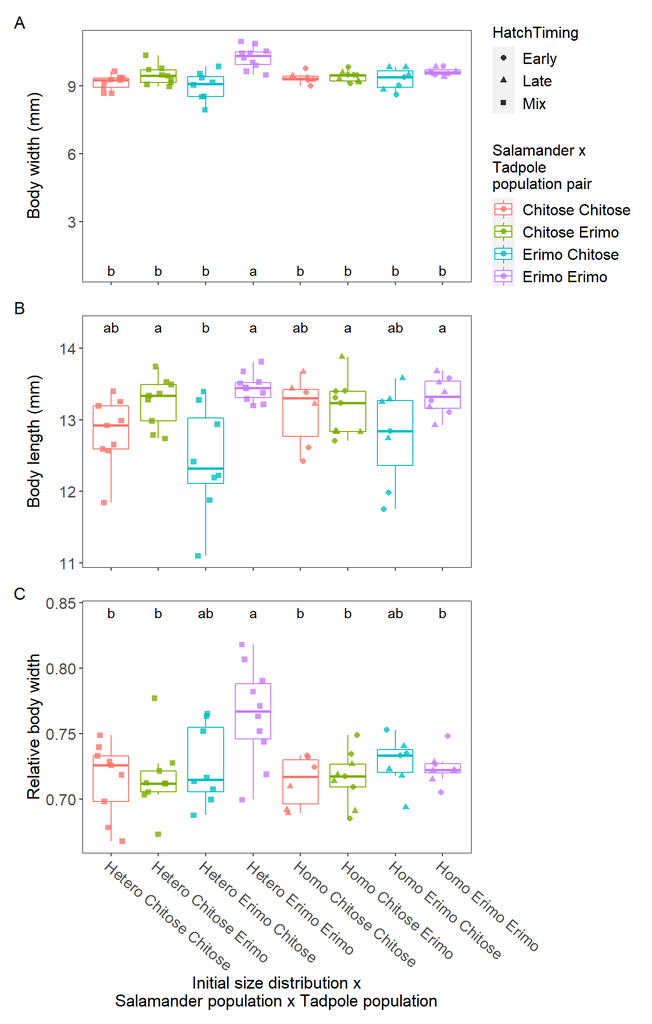

```r
> (`p.Body width (mm)` +
+     `p.Body length (mm)`*
+      theme(legend.position = 'none')
+   )*
+   theme(
+     axis.text.x = element_blank(),
+     axis.title.x = element_blank()
+     ) +
+   `p.Relative body width`*
+      theme(legend.position = 'none') +
+   plot_layout(ncol = 1) +
+   plot_annotation(tag_levels = 'A')
```

```r
> dat %>%
+   group_by(Treat) %>%
+   summarise(N = length(ID)) %>%
+   kable("html", caption = "Sample size") %>%
+   kable_styling("striped", position = "left")
```

Sample size

| Treat | N |
| --- | --- |
| Hetero Chitose Chitose | 9 |
| Hetero Chitose Erimo | 9 |
| Hetero Erimo Chitose | 8 |
| Hetero Erimo Erimo | 10 |
| Homo Chitose Chitose | 6 |
| Homo Chitose Erimo | 9 |
| Homo Erimo Chitose | 7 |
| Homo Erimo Erimo | 8 |

# Counting potential predator

```r
> left_join(
+   # Salamander gape width data
+   dat.sal.tidy %>%
+     select(c("ID", "Individual", "Gape width (mm)")) %>%
+     rename("Gape.width" = "Gape width (mm)"),
+   # Tadpole body width data (tank mean)
+   dat.tad %>%
+     group_by(ID) %>%
+     summarise(Tad.width.mean = mean(`Body.width.(mm)`, na.rm = TRUE)),
+   by = "ID"
+   ) %>%
+   drop_na %>%
+   group_by(ID) %>%
+   # Count potential predator at each tank
+   summarise(
+     Potential_predator = length(Gape.width[Gape.width > Tad.width.mean]),
+   ) %>%
+   ungroup %>%
+   right_join(IDs, ., by = "ID") %>%
+   # Summarise potential predator frequency in each treatment
+   group_by(Treat) %>%
+   summarise(
+     # N of tank in each treatment
+     Tank_examined = length(Potential_predator),
+     # N of tank with "Potential predators"
+     Tank_with_potential_predator = length(ID[Potential_predator >= 1]),
+     # Mean N of "Potential predators"
+     Mean_potential_predator_count = mean(Potential_predator)
+     ) %>%
+   kable("html", digits = 2, caption = "Potential predator emergence") %>%
+   kable_styling("striped", position = "left")
```

Potential predator emergence

| Treat | Tank_examined | Tank_with_potential_predator | Mean_potential_predator_count |
| --- | --- | --- | --- |
| Hetero Chitose Chitose | 9 | 0 | 0.00 |
| Hetero Chitose Erimo | 9 | 0 | 0.00 |
| Hetero Erimo Chitose | 8 | 6 | 1.38 |
| Hetero Erimo Erimo | 10 | 4 | 0.50 |
| Homo Chitose Chitose | 6 | 0 | 0.00 |
| Homo Chitose Erimo | 9 | 0 | 0.00 |
| Homo Erimo Chitose | 7 | 0 | 0.00 |
| Homo Erimo Erimo | 8 | 0 | 0.00 |

# **Appendix S1** Comparing size homogenous sub-treatments

By manipulating salamander hatch timing, we established an initial size heterogeneity treatment and two initial size homogenous sub-treatments differing in the hatch timing (early and late) at the beginning of the experiment. We expected that salamander and tadpole mortality did not differ between the size homogenous sub-treatments within salamander–tadpole population pairs because salamander cannibalism should be rare and thus the offensive giant salamanders should also rarely emerge in those treatments. As salamanders in size homogenous treatments are expected to be harmless for tadpoles, we also anticipated that tadpole morphology did not differ between the size homogenous sub-treatments in each salamander–tadpole population pair (i.e. following four pairs are our interest: Chitose salamander– Chitose tadpole–early hatch vs. –late hatch; Chitose salamander– Erimo tadpole–early hatch vs. –late hatch; Erimo salamander–Chitose tadpole–early hatch vs. –late hatch; Erimo salamander–Erimo tadpole–early hatch vs. –late hatch). If these expectations—mortality and morphology of both species did not differ between sub-treatments within salamander–tadpole populations pair—are satisfied, we can pool data of the sub-treatments within each salamander-tadpole populations pair.

We employed a one-way ANOVA test or Scheirer–Ray–Hare (SRH) test followed by Tukey HSD test to compare the sub-treatments across all population pairs. We used the same data as for the main analyses: salamander mortality by day 18; tadpole mortality by day 32; and morphology of both species at day 18. While we used an ANOVA for morphological data, we used a SRH test for the mortality data because the mortality of both species were highly zero-inflated (see Materials and Methods, Statistical analyses).

In the mortality of both species, SRH detected significant heterogeneity across treatments (salamander, SRH = 49.40, P < 0.001; tadpole, SRH = 49.61, P < 0.001). However, the post-hoc Tukey HSD test did not detect any differences between the sub-treatments (Fig. S1A and S1B for salamander and tadpole, respectively). ANOVA detected significant heterogeneity across treatments in salamander morphology (gape width, F = 28.19, P < 0.001; trunk length, F = 8.03, P < 0.001; relative gape width, F = 13.01, P < 0.001) and tadpole morphology (body width, F = 5.38, P < 0.001; body length, F = 4.34, P < 0.001; relative body width, F = 2.82, P = 0.006). As with mortality, however, the post-hoc Tukey HSD test did not detect any morphological differences between the sub-treatments in each population pair (salamander gape width, Fig. S2A; salamander trunk length, Fig. S2B; salamander relative gape width, Fig. S2C; tadpole body width, Fig. S3A; tadpole body length, Fig. S3B; tadpole relative body width, Fig. S3C).

Overall, the mortality and morphology of both species did not differ between the two alternative hatch timing conditions within each population pair. We therefore pooled the data of the two initial size homogenous sub-treatments.

### Interaction strength

```r
> for (sp in c("sal", "tad")) {
+
+   if (sp == "sal") {
+
+   # add ranked variable to dataframe
+   dat <- timeser.dat %>%
+     filter(Period == 2) %>%
+     mutate(SalxTadxHatchtiming = str_c(Sal, Tad, HatchTiming, sep = " "))
+
+   p <- ggplot(dat, aes(x = SalxTadxHatchtiming, y = Mort.sal))
+
+   } else {
+
+   # add ranked variable to dataframe
+   dat <- timeser.dat %>%
+     filter(Period == 4) %>%
+     mutate(SalxTadxHatchtiming = str_c(Sal, Tad, HatchTiming, sep = " "))
+
+   p <- ggplot(dat, aes(x = SalxTadxHatchtiming, y = Mort.tad))
+
+   }
+
+    p2 <- p +
+     geom_boxplot(aes(colour = SalxTad), outlier.shape = NA) +
+     geom_point(
+       mapping = aes(shape = HatchTiming, colour = SalxTad),
+       position = position_jitter(width = 0.3, height = 0),
+       alpha = 0.8, size = 2.3
+       ) +
+      labs(
+        y = cap[sp,],
+        x = "Salamander population x Tadpole population x Hatch timing",
+        colour =
+        "Salamander x
+ Tadpole
+ population pair"
+      ) +
+     mytheme
+
+   #+++++++++++++++++++++++++++++++++++++++++++++++#
+   # Full model including interaction terms
+   #+++++++++++++++++++++++++++++++++++++++++++++++#
+   dat$rank <- rank(dat[, paste0("Mort.",sp)])
+
+   srh_res <- SRH_fun(aov(rank ~ SalxTadxHatchtiming, data = dat))$SRH.out.table
+   srh_res %>%
+     kable("html", 4, caption = paste("SRH:", cap[sp,])) %>%
+     kable_styling("striped", position = "left") %>%
+     print
+
+   #+++++++++++++++++++++++++++++++++++++++++++++#
+   # If ANOVA is (marginally) significant
+   #+++++++++++++++++++++++++++++++++++++++++++++#
+   if (srh_res$P < 0.06) {
+
+     # Tukey
+     Tukey.group <- HSD.test(
+         aov(rank ~ SalxTadxHatchtiming, data = dat),
+         "SalxTadxHatchtiming", group = TRUE
+       )$groups %>% dplyr::select(groups) %>%
+         mutate(SalxTadxHatchtiming = rownames(.))
+
+     # Tukey
+     TukeyHSD(
+         aov(rank ~ SalxTadxHatchtiming, data = dat),
+         "SalxTadxHatchtiming", group = TRUE
+       )$SalxTadxHatchtiming %>%
+       as.data.frame %>%
+       rownames_to_column("Comp") %>%
+       dplyr::select("Comp", "p adj") %>%
+       filter(
+         Comp == "Chitose Chitose Late-Chitose Chitose Early" |
+         Comp == "Chitose Erimo Late-Chitose Erimo Early" |
+         Comp == "Erimo Erimo Late-Erimo Erimo Early" |
+         Comp == "Erimo Chitose Late-Erimo Chitose Early"
+         ) %>%
+       kable(
+         "html", digits = 4,
+         caption = "Tukey HSD results for each population pair comparison"
+         ) %>%
+       kable_styling("striped", position = "left")  %>%
+       print()
+
+
+      p3 <- p2 +
+       geom_text(
+         data = Tukey.group,
+         aes(x = SalxTadxHatchtiming, y = -0.7, label = groups)
+         )
+
+   #+++++++++++++++++++++++++++++++++++++++++++++#
+   # If ANOVA is non-significant
+   #+++++++++++++++++++++++++++++++++++++++++++++#
+   } else {
+
+     p3 <- p2
+
+   }
+
+   # print(p3)
+
+   assign(paste0("p.", sp), p3)
+
+   #+++++++++++++++++++++++++++++++++++++++++++++#
+   # Adjusted P of t-tests for same pop pairs
+   #+++++++++++++++++++++++++++++++++++++++++++++#
+
+   for (combi in levels(dat$SalxTad)) {
+
+     Early <- dat %>%
+       filter(SalxTadxHatchtiming == paste(combi, "Early", sep = " "))
+
+     Late <- dat %>%
+       filter(SalxTadxHatchtiming == paste(combi, "Late", sep = " "))
+
+     # Cases if Early & Late are the same
+     if (Early$rank == Late$rank) {
+
+       assign(
+         paste("Comp", combi, sep = "_"),
+         tibble(
+           Pair = combi,
+           P = 1
+         )
+       )
+
+     } else {
+
+       assign(
+         paste("Comp", combi, sep = "_"),
+         tibble(
+           Pair = combi,
+           P = t.test(Early$rank, Late$rank)$p.value
+           )
+       )
+
+     }
+
+   }
+
+   # Comp <- bind_rows(
+   #   `Comp_Chitose Chitose`,
+   #   `Comp_Chitose Erimo`,
+   #   `Comp_Erimo Chitose`,
+   #   `Comp_Erimo Erimo`
+   #   )
+   # Comp$Padj <- p.adjust(Comp$P, "BH")
+   # Comp %>%
+   #   kable("html", 4, caption = paste("Benjamini & Hochberg adjusted P:", cap[i,])) %>%
+   #   kable_styling("striped", position = "left") %>%
+   #   print
+
+ }
```

SRH: Salamander mortality (count) by day 18

Factor

Df

SRH

P

Significance

SalxTadxHatchtiming

11

49.3963

0

Tukey HSD results for each population pair comparison

| Comp | p adj |
| --- | --- |
| Chitose Chitose Late-Chitose Chitose Early | 0.8264 |
| Chitose Erimo Late-Chitose Erimo Early | 1.0000 |
| Erimo Chitose Late-Erimo Chitose Early | 1.0000 |
| Erimo Erimo Late-Erimo Erimo Early | 0.9983 |

SRH: Tadpole mortality (count) by day 32

Factor

Df

SRH

P

Significance

SalxTadxHatchtiming

11

49.6113

0

Tukey HSD results for each population pair comparison

| Comp | p adj |
| --- | --- |
| Chitose Chitose Late-Chitose Chitose Early | 1.0000 |
| Chitose Erimo Late-Chitose Erimo Early | 0.9997 |
| Erimo Chitose Late-Erimo Chitose Early | 0.9997 |
| Erimo Erimo Late-Erimo Erimo Early | 0.9126 |

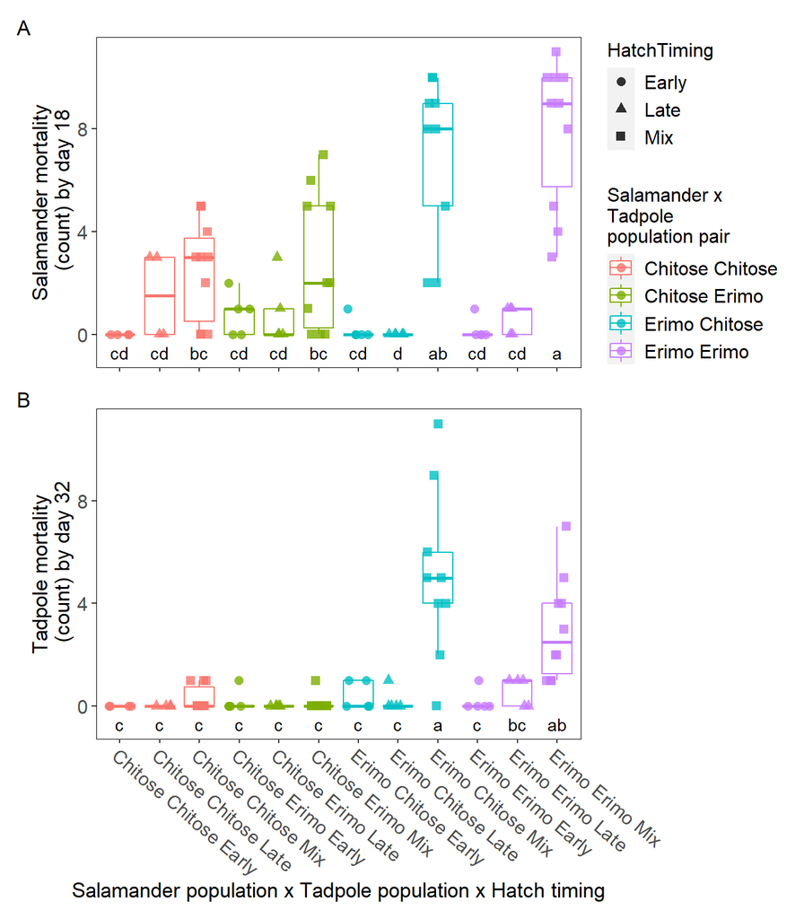

```r
> p.sal*
+   theme(
+     axis.text.x = element_blank(),
+     axis.title.x = element_blank()
+     ) +
+   p.tad*
+     theme(legend.position = 'none') +
+   plot_layout(ncol = 1) +
+   plot_annotation(tag_levels = 'A')
```

**Fig. S1** Salamander mortality by day 18 (**A**) and tadpole mortality by day 32 (**B**), shown by boxplot with raw data points. “*Early*”, “*Late*”, and “*Mix*” hatch timing indicates initial size homogenous treatments with early hatch timing and late hatch timing, and initial size heterogenous treatment, respectively. Treatments sharing the same alphabet letter are not significantly different (Tukey’s HSD for ranked variable).

### Salamander morphology

```r
> for (tr in levels(largest.jaw.tidy$Trait)) {
+
+   dat <- filter(largest.jaw.tidy, Trait == tr)
+
+   # ANOVA
+   anova <- summary(aov(scale(dat$measure) ~ SalxTadxHatchtiming, data = dat))[[1]]
+   ANOVA_stats(anova) %>%
+     kable("html", digits = 3, caption = paste(tr, "ANOVA")) %>%
+     kable_styling("striped", position = "left") %>%
+     print()
+
+   p <- ggplot(dat, aes(x = SalxTadxHatchtiming, y = measure)) +
+     geom_boxplot(aes(colour = SalxTad), outlier.shape = NA) +
+     geom_point(
+       mapping = aes(shape = HatchTiming, colour = SalxTad),
+       position = position_jitter(width = 0.3, height = 0),
+       alpha = 0.8, size = 1.7
+       ) +
+      labs(
+        y = tr,
+        x = "Salamander population x Tadpole population x
+        Hatch timing",
+        colour =
+        "Salamander x
+ Tadpole
+ population pair"
+      ) +
+      labs(
+        y = tr,
+        x = "Salamander population x Tadpole population x Hatch timing",
+        colour =
+        "Salamander x
+ Tadpole
+ population pair"
+      ) +
+     mytheme
+
+   #+++++++++++++++++++++++++++++++++++++++++++++#
+   # If ANOVA is (marginally) significant
+   #+++++++++++++++++++++++++++++++++++++++++++++#
+   if (anova["SalxTadxHatchtiming", "Pr(>F)"] < 0.06) {
+
+     # Tukey
+     Tukey.group <- HSD.test(
+         aov(measure ~ SalxTadxHatchtiming, data = dat),
+         "SalxTadxHatchtiming", group = TRUE
+       )$groups %>% dplyr::select(groups) %>%
+         mutate(SalxTadxHatchtiming = rownames(.))
+
+     if (tr == "Gape width (mm)") {
+
+       p2 <- p +
+         geom_text(
+           data = Tukey.group,
+           aes(x = SalxTadxHatchtiming, y = max.val["Gape width (mm)","measure"]*1.1, label = groups)
+           )
+
+     } else {
+
+       if (tr == "Trunk length (mm)") {
+
+         p2 <- p +
+             geom_text(
+               data = Tukey.group,
+               aes(x = SalxTadxHatchtiming, y = max.val["Trunk length (mm)","measure"]*1.1, label = groups)
+               )
+
+       } else {
+
+         p2 <- p +
+             geom_text(
+               data = Tukey.group,
+               aes(x = SalxTadxHatchtiming, y = max.val["Relative gape width","measure"]*1.1, label = groups)
+               )
+
+       }
+     }
+
+     # Tukey
+     TukeyHSD(
+         aov(measure ~ SalxTadxHatchtiming, data = dat),
+         "SalxTadxHatchtiming", group = TRUE
+       )$SalxTadxHatchtiming %>%
+       as.data.frame %>%
+       rownames_to_column("Comp") %>%
+       dplyr::select("Comp", "p adj") %>%
+       filter(
+         Comp == "Chitose Chitose Late-Chitose Chitose Early" |
+         Comp == "Chitose Erimo Late-Chitose Erimo Early" |
+         Comp == "Erimo Erimo Late-Erimo Erimo Early" |
+         Comp == "Erimo Chitose Late-Erimo Chitose Early"
+         ) %>%
+       kable(
+         "html", digits = 4,
+         caption = paste("Tukey HSD results for each population pair comparison:", tr)
+         ) %>%
+       kable_styling("striped", position = "left")  %>%
+       print()
+
+   #+++++++++++++++++++++++++++++++++++++++++++++#
+   # If ANOVA is non-significant
+   #+++++++++++++++++++++++++++++++++++++++++++++#
+   } else {
+
+     p2 <- p
+
+   }
+
+   # print(p2)
+   assign(paste0("p.", tr), p2)
+
+ }
```

Gape width (mm) ANOVA

Factors

SS

d.f.

F

P

significance

SalxTadxHatchtiming

62.829

11

28.188

<0.001

Residuals

13.171

65

Tukey HSD results for each population pair comparison: Gape width (mm)

| Comp | p adj |
| --- | --- |
| Chitose Chitose Late-Chitose Chitose Early | 0.9306 |
| Chitose Erimo Late-Chitose Erimo Early | 0.8116 |
| Erimo Chitose Late-Erimo Chitose Early | 0.1632 |
| Erimo Erimo Late-Erimo Erimo Early | 0.9656 |

Trunk length (mm) ANOVA

Factors

SS

d.f.

F

P

significance

SalxTadxHatchtiming

43.788

11

8.033

<0.001

Residuals

32.212

65

Tukey HSD results for each population pair comparison: Trunk length (mm)

| Comp | p adj |
| --- | --- |
| Chitose Chitose Late-Chitose Chitose Early | 0.6090 |
| Chitose Erimo Late-Chitose Erimo Early | 0.9160 |
| Erimo Chitose Late-Erimo Chitose Early | 0.9955 |
| Erimo Erimo Late-Erimo Erimo Early | 0.4896 |

Relative gape width ANOVA

Factors

SS

d.f.

F

P

significance

SalxTadxHatchtiming

52.265

11

13.012

<0.001

Residuals

23.735

65

Tukey HSD results for each population pair comparison: Relative gape width

| Comp | p adj |
| --- | --- |
| Chitose Chitose Late-Chitose Chitose Early | 1.0000 |
| Chitose Erimo Late-Chitose Erimo Early | 0.9913 |
| Erimo Chitose Late-Erimo Chitose Early | 0.5091 |
| Erimo Erimo Late-Erimo Erimo Early | 1.0000 |

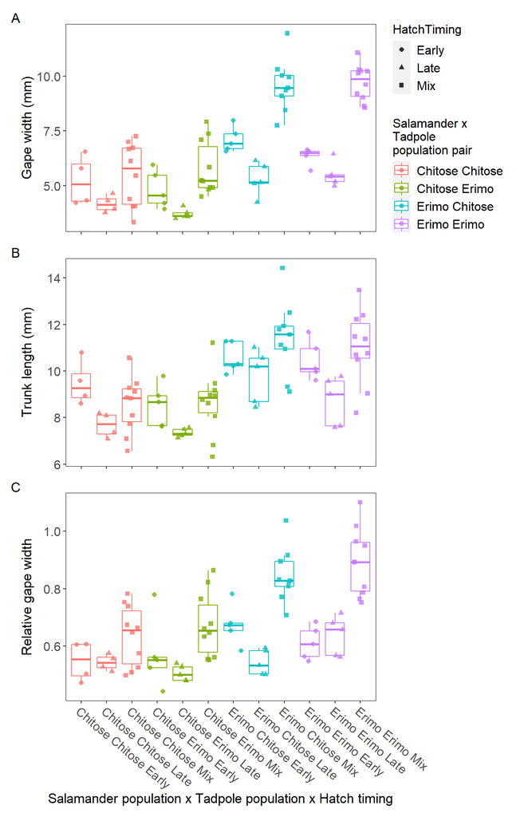

```r
> #+++++++++++++++++++++++++++++++#
> # Plot
> #+++++++++++++++++++++++++++++++#
>
> (`p.Gape width (mm)` +
+     `p.Trunk length (mm)`*
+      theme(legend.position = 'none')
+   )*
+   theme(
+     axis.text.x = element_blank(),
+     axis.title.x = element_blank()
+     ) +
+   `p.Relative gape width`*
+      theme(legend.position = 'none') +
+   plot_layout(ncol = 1) +
+   plot_annotation(tag_levels = 'A')
```

### Tadpole morphology

```r
> for (tr in levels(dat.tad.sum$Trait)) {
+
+   dat <- filter(dat.tad.sum, Trait == tr)
+
+   # ANOVA
+   anova <- summary(aov(scale(dat$measure) ~ SalxTadxHatchtiming, data = dat))[[1]]
+   ANOVA_stats(anova) %>%
+     kable("html", digits = 3, caption = paste(tr, "ANOVA")) %>%
+     kable_styling("striped", position = "left") %>%
+     print()
+
+   p <- ggplot(dat, aes(x = SalxTadxHatchtiming, y = measure)) +
+     geom_boxplot(aes(colour = SalxTad), outlier.shape = NA) +
+     geom_point(
+       mapping = aes(shape = HatchTiming, colour = SalxTad),
+       position = position_jitter(width = 0.3, height = 0),
+       alpha = 0.8, size = 1.7
+       ) +
+      labs(
+        y = tr,
+        x = "Salamander population x Tadpole population x
+        Hatch timing",
+        colour =
+        "Salamander x
+ Tadpole
+ population pair"
+      ) +
+      labs(
+        y = tr,
+        x = "Salamander population x Tadpole population x Hatch timing",
+        colour =
+        "Salamander x
+ Tadpole
+ population pair"
+      ) +
+     mytheme
+
+   #+++++++++++++++++++++++++++++++++++++++++++++#
+   # If ANOVA is (marginally) significant
+   #+++++++++++++++++++++++++++++++++++++++++++++#
+   if (anova["SalxTadxHatchtiming", "Pr(>F)"] < 0.06) {
+
+     # Tukey
+     Tukey.group <- HSD.test(
+         aov(measure ~ SalxTadxHatchtiming, data = dat),
+         "SalxTadxHatchtiming", group = TRUE
+       )$groups %>% dplyr::select(groups) %>%
+         mutate(SalxTadxHatchtiming = rownames(.))
+
+     if (i == "Body width (mm)") {
+
+       p2 <- p +
+         geom_text(
+           data = Tukey.group,
+           aes(x = SalxTadxHatchtiming, y = max.val["Body width (mm)","measure"]*1.03, label = groups)
+           )
+
+     } else {
+
+       if (tr == "Body length (mm)") {
+
+         p2 <- p +
+             geom_text(
+               data = Tukey.group,
+               aes(x = SalxTadxHatchtiming, y = max.val["Body length (mm)","measure"]*1.03, label = groups)
+               )
+
+       } else {
+
+         p2 <- p +
+             geom_text(
+               data = Tukey.group,
+               aes(x = SalxTadxHatchtiming, y = max.val["Relative body width","measure"]*1.03, label = groups)
+               )
+
+       }
+     }
+
+     # Tukey
+     TukeyHSD(
+         aov(measure ~ SalxTadxHatchtiming, data = dat),
+         "SalxTadxHatchtiming", group = TRUE
+       )$SalxTadxHatchtiming %>%
+       as.data.frame %>%
+       rownames_to_column("Comp") %>%
+       dplyr::select("Comp", "p adj") %>%
+       filter(
+         Comp == "Chitose Chitose Late-Chitose Chitose Early" |
+         Comp == "Chitose Erimo Late-Chitose Erimo Early" |
+         Comp == "Erimo Erimo Late-Erimo Erimo Early" |
+         Comp == "Erimo Chitose Late-Erimo Chitose Early"
+         ) %>%
+       kable(
+         "html", digits = 4,
+         caption = paste("Tukey HSD results for each population pair comparison:", tr)
+         ) %>%
+       kable_styling("striped", position = "left")  %>%
+       print()
+
+   #+++++++++++++++++++++++++++++++++++++++++++++#
+   # If ANOVA is non-significant
+   #+++++++++++++++++++++++++++++++++++++++++++++#
+   } else {
+
+     p2 <- p
+
+   }
+
+   # print(p2)
+
+   assign(paste0("p.", tr), p2)
+
+   # #+++++++++++++++++++++++++++++++++++++++++++++#
+   # # Adjusted P of t-tests for same pop pairs
+   # #+++++++++++++++++++++++++++++++++++++++++++++#
+   # for (h in levels(dat$SalxTad)) {
+   #
+   #   Early <- dat %>%
+   #     filter(SalxTadxHatchtiming == paste(h, "Early", sep = " "))
+   #
+   #   Late <- dat %>%
+   #     filter(SalxTadxHatchtiming == paste(h, "Late", sep = " "))
+   #
+   #   assign(
+   #     paste("Comp", h, sep = "_"),
+   #     tibble(
+   #       Pair = h,
+   #       P = t.test(Early$measure, Late$measure)$p.value
+   #       )
+   #   )
+   #
+   # }
+   #
+   # Comp <- bind_rows(
+   #   `Comp_Chitose Chitose`,
+   #   `Comp_Chitose Erimo`,
+   #   `Comp_Erimo Chitose`,
+   #   `Comp_Erimo Erimo`
+   #   )
+   # Comp$Padj <- p.adjust(Comp$P, "BH")
+   # Comp %>%
+   #   kable("html", 4, caption = paste("Benjamini & Hochberg adjusted P:", i)) %>%
+   #   kable_styling("striped", position = "left") %>%
+   #   print
+
+ }
```

Body width (mm) ANOVA

Factors

SS

d.f.

F

P

significance

SalxTadxHatchtiming

34.001

11

5.384

<0.001

Residuals

30.999

54

Tukey HSD results for each population pair comparison: Body width (mm)

| Comp | p adj |
| --- | --- |
| Chitose Chitose Late-Chitose Chitose Early | 1.0000 |
| Chitose Erimo Late-Chitose Erimo Early | 1.0000 |
| Erimo Chitose Late-Erimo Chitose Early | 0.9085 |
| Erimo Erimo Late-Erimo Erimo Early | 1.0000 |

Body length (mm) ANOVA

Factors

SS

d.f.

F

P

significance

SalxTadxHatchtiming

30.51

11

4.342

<0.001

Residuals

34.49

54

Tukey HSD results for each population pair comparison: Body length (mm)

| Comp | p adj |
| --- | --- |
| Chitose Chitose Late-Chitose Chitose Early | 0.8252 |
| Chitose Erimo Late-Chitose Erimo Early | 1.0000 |
| Erimo Chitose Late-Erimo Chitose Early | 0.1248 |
| Erimo Erimo Late-Erimo Erimo Early | 1.0000 |

Relative body width ANOVA

Factors

SS

d.f.

F

P

significance

SalxTadxHatchtiming

23.692

11

2.816

0.006

Residuals

41.308

54

Tukey HSD results for each population pair comparison: Relative body width

| Comp | p adj |
| --- | --- |
| Chitose Chitose Late-Chitose Chitose Early | 0.9212 |
| Chitose Erimo Late-Chitose Erimo Early | 1.0000 |
| Erimo Chitose Late-Erimo Chitose Early | 0.9942 |
| Erimo Erimo Late-Erimo Erimo Early | 1.0000 |

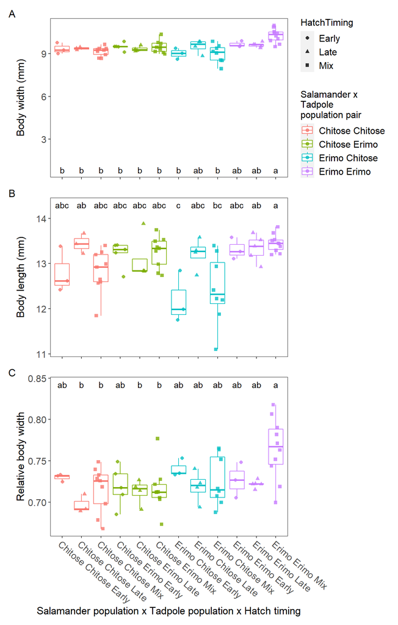

```r
> (`p.Body width (mm)` +
+     `p.Body length (mm)`*
+      theme(legend.position = 'none')
+   )*
+   theme(
+     axis.text.x = element_blank(),
+     axis.title.x = element_blank()
+     ) +
+   `p.Relative body width`*
+      theme(legend.position = 'none') +
+   plot_layout(ncol = 1) +
+   plot_annotation(tag_levels = 'A')
```

```r
> # dat %>%
> #   group_by(SalxTadxHatchtiming) %>%
> #   summarise(N = length(ID)) %>%
> #   kable("html", caption = "Sample size") %>%
> #   kable_styling("striped", position = "left")
```

**Fig. S3** Tadpole morphology (**A**, body width; **B**, body length; **C**, relative body width) at day 18, shown by boxplot with raw data points. For hatch timing, see Fig. S1. Treatments sharing the same alphabet letter are not significantly different (Tukey’s HSD).